# Supervised Learning - Foundations Project: ReCell

## Problem Statement

### Business Context

Buying and selling used phones and tablets used to be something that happened on a handful of online marketplace sites. But the used and refurbished device market has grown considerably over the past decade, and a new IDC (International Data Corporation) forecast predicts that the used phone market would be worth \$52.7bn by 2023 with a compound annual growth rate (CAGR) of 13.6% from 2018 to 2023. This growth can be attributed to an uptick in demand for used phones and tablets that offer considerable savings compared with new models.

Refurbished and used devices continue to provide cost-effective alternatives to both consumers and businesses that are looking to save money when purchasing one. There are plenty of other benefits associated with the used device market. Used and refurbished devices can be sold with warranties and can also be insured with proof of purchase. Third-party vendors/platforms, such as Verizon, Amazon, etc., provide attractive offers to customers for refurbished devices. Maximizing the longevity of devices through second-hand trade also reduces their environmental impact and helps in recycling and reducing waste. The impact of the COVID-19 outbreak may further boost this segment as consumers cut back on discretionary spending and buy phones and tablets only for immediate needs.

### Objective

The rising potential of this comparatively under-the-radar market fuels the need for an ML-based solution to develop a dynamic pricing strategy for used and refurbished devices. ReCell, a startup aiming to tap the potential in this market, has hired you as a data scientist. They want you to analyze the data provided and build a linear regression model to predict the price of a used phone/tablet and identify factors that significantly influence it.

### Data Description

The data contains the different attributes of used/refurbished phones and tablets. The data was collected in the year 2021. The detailed data dictionary is given below.

- brand_name: Name of manufacturing brand
- os: OS on which the device runs
- screen_size: Size of the screen in cm
- 4g: Whether 4G is available or not
- 5g: Whether 5G is available or not
- main_camera_mp: Resolution of the rear camera in megapixels
- selfie_camera_mp: Resolution of the front camera in megapixels
- int_memory: Amount of internal memory (ROM) in GB
- ram: Amount of RAM in GB
- battery: Energy capacity of the device battery in mAh
- weight: Weight of the device in grams
- release_year: Year when the device model was released
- days_used: Number of days the used/refurbished device has been used
- normalized_new_price: Normalized price of a new device of the same model in euros
- normalized_used_price: Normalized price of the used/refurbished device in euros

## Summary

### Actionable Insights and Recommendations

1. The model explains nearly **84% of the variation** in used phone prices and can **predict prices with ~4.5% error** on unseen data.
   - This makes it a **reliable model** for both pricing strategies and understanding market drivers.
2. **A 1-unit increase in screen size** is associated with an **increase of 0.0433 units** in normalized price, keeping other variables constant.
   - Larger screens contribute positively to value — manufacturers can promote larger displays as a selling point.
3. **Higher camera specifications** also increase value:
   - `main_camera_mp`: +0.0189 units
   - `selfie_camera_mp`: +0.0131 units
   - Phones with better cameras tend to retain higher used value. Marketing can highlight camera features.
4. **RAM** contributes positively (+0.0172), reinforcing the importance of memory for buyers.
5. **Years since release** has a negative effect (–0.0181 per year), as expected — older phones lose value over time.
6. Certain brands (e.g., `Xiaomi`, `Nokia`, `Lenovo`) have a positive brand effect on value:
   - `Xiaomi`: +0.0852
   - `Nokia`: +0.0733
   - `Lenovo`: +0.0489
7. Phones with **4G support** are valued **+0.0369 units higher** than those without — connectivity continues to influence price.
8. The company can:
   - Use this model to **automate or guide pricing** of used devices.
   - **Promote phones** with large screens, high RAM, and better cameras to increase resale appeal.
   - Highlight **brand value and connectivity features** when targeting used phone markets.

## Importing necessary libraries

```python
# Installing the libraries with the specified version.
# uncomment and run the following line if Google Colab is being used
# !pip install scikit-learn==1.2.2 seaborn==0.13.1 matplotlib==3.7.1 numpy==1.25.2 pandas==1.5.3 -q --user
```

```python
# Installing the libraries with the specified version.
# uncomment and run the following lines if Jupyter Notebook is being used
# !pip install scikit-learn==1.2.2 seaborn==0.11.1 matplotlib==3.3.4 numpy==1.24.3 pandas==1.5.2 -q --user
```

**Note**: *After running the above cell, kindly restart the notebook kernel and run all cells sequentially from the start again.*

```python
# Libraries to help with reading and manipulating data
import numpy as np
import pandas as pd

# Libraries to help with data visualization
import matplotlib.pyplot as plt
import seaborn as sns

sns.set()

# split the data into train and test
from sklearn.model_selection import train_test_split

# to build linear regression_model
import statsmodels.api as sm

# to check model performance
from sklearn.metrics import mean_absolute_error, mean_squared_error, r2_score
```

## Loading the dataset

```python
# uncomment and run the following lines for mounting Google Drive to the notebook (to be used only if executing in Google Colab)
# from google.colab import drive
# drive.mount('/content/drive')
```

```python
data = pd.read_csv("used_device_data.csv")
```

## Data Overview

- Observations
- Sanity checks

### Displaying the first few rows of the dataset

```python
data.head()
```

|  | brand_name | os | screen_size | 4g | 5g | main_camera_mp | selfie_camera_mp | int_memory | ram | battery | weight | release_year | days_used | normalized_used_price | normalized_new_price |
| --- | --- | --- | --- | --- | --- | --- | --- | --- | --- | --- | --- | --- | --- | --- | --- |
| 0 | Honor | Android | 14.50 | yes | no | 13.0 | 5.0 | 64.0 | 3.0 | 3020.0 | 146.0 | 2020 | 127 | 4.307572 | 4.715100 |
| 1 | Honor | Android | 17.30 | yes | yes | 13.0 | 16.0 | 128.0 | 8.0 | 4300.0 | 213.0 | 2020 | 325 | 5.162097 | 5.519018 |
| 2 | Honor | Android | 16.69 | yes | yes | 13.0 | 8.0 | 128.0 | 8.0 | 4200.0 | 213.0 | 2020 | 162 | 5.111084 | 5.884631 |
| 3 | Honor | Android | 25.50 | yes | yes | 13.0 | 8.0 | 64.0 | 6.0 | 7250.0 | 480.0 | 2020 | 345 | 5.135387 | 5.630961 |
| 4 | Honor | Android | 15.32 | yes | no | 13.0 | 8.0 | 64.0 | 3.0 | 5000.0 | 185.0 | 2020 | 293 | 4.389995 | 4.947837 |

The dataset contains information about used/refurbished phones and tablets

### Checking the shape of the dataset

```python
data.shape
```

```
(3454, 15)
```

The dataset contains information (15 attributes) about 3454 phones & tablets

### Checking the data types of the columns for the dataset

```python
data.info()
```

```
<class 'pandas.core.frame.DataFrame'>
RangeIndex: 3454 entries, 0 to 3453
Data columns (total 15 columns):
 #   Column                 Non-Null Count  Dtype
---  ------                 --------------  -----
 0   brand_name             3454 non-null   object
 1   os                     3454 non-null   object
 2   screen_size            3454 non-null   float64
 3   4g                     3454 non-null   object
 4   5g                     3454 non-null   object
 5   main_camera_mp         3275 non-null   float64
 6   selfie_camera_mp       3452 non-null   float64
 7   int_memory             3450 non-null   float64
 8   ram                    3450 non-null   float64
 9   battery                3448 non-null   float64
 10  weight                 3447 non-null   float64
 11  release_year           3454 non-null   int64
 12  days_used              3454 non-null   int64
 13  normalized_used_price  3454 non-null   float64
 14  normalized_new_price   3454 non-null   float64
dtypes: float64(9), int64(2), object(4)
memory usage: 404.9+ KB
```

- There are 11 numeric (*float* and *int* type) and 4 string (*object* type) columns in the data
- The target variable is the normalized_used_price, which is of *float* type

### Statistical summary of the dataset

```python
data.describe(include="all").T
```

|  | count | unique | top | freq | mean | std | min | 25% | 50% | 75% | max |
| --- | --- | --- | --- | --- | --- | --- | --- | --- | --- | --- | --- |
| brand_name | 3454 | 34 | Others | 502 | NaN | NaN | NaN | NaN | NaN | NaN | NaN |
| os | 3454 | 4 | Android | 3214 | NaN | NaN | NaN | NaN | NaN | NaN | NaN |
| screen_size | 3454.0 | NaN | NaN | NaN | 13.713115 | 3.80528 | 5.08 | 12.7 | 12.83 | 15.34 | 30.71 |
| 4g | 3454 | 2 | yes | 2335 | NaN | NaN | NaN | NaN | NaN | NaN | NaN |
| 5g | 3454 | 2 | no | 3302 | NaN | NaN | NaN | NaN | NaN | NaN | NaN |
| main_camera_mp | 3275.0 | NaN | NaN | NaN | 9.460208 | 4.815461 | 0.08 | 5.0 | 8.0 | 13.0 | 48.0 |
| selfie_camera_mp | 3452.0 | NaN | NaN | NaN | 6.554229 | 6.970372 | 0.0 | 2.0 | 5.0 | 8.0 | 32.0 |
| int_memory | 3450.0 | NaN | NaN | NaN | 54.573099 | 84.972371 | 0.01 | 16.0 | 32.0 | 64.0 | 1024.0 |
| ram | 3450.0 | NaN | NaN | NaN | 4.036122 | 1.365105 | 0.02 | 4.0 | 4.0 | 4.0 | 12.0 |
| battery | 3448.0 | NaN | NaN | NaN | 3133.402697 | 1299.682844 | 500.0 | 2100.0 | 3000.0 | 4000.0 | 9720.0 |
| weight | 3447.0 | NaN | NaN | NaN | 182.751871 | 88.413228 | 69.0 | 142.0 | 160.0 | 185.0 | 855.0 |
| release_year | 3454.0 | NaN | NaN | NaN | 2015.965258 | 2.298455 | 2013.0 | 2014.0 | 2015.5 | 2018.0 | 2020.0 |
| days_used | 3454.0 | NaN | NaN | NaN | 674.869716 | 248.580166 | 91.0 | 533.5 | 690.5 | 868.75 | 1094.0 |
| normalized_used_price | 3454.0 | NaN | NaN | NaN | 4.364712 | 0.588914 | 1.536867 | 4.033931 | 4.405133 | 4.7557 | 6.619433 |
| normalized_new_price | 3454.0 | NaN | NaN | NaN | 5.233107 | 0.683637 | 2.901422 | 4.790342 | 5.245892 | 5.673718 | 7.847841 |

### Checking for duplicate values

```python
data.duplicated().sum()
```

```
0
```

- There are no duplicate values in the data

### Checking for missing values

```python
data.isnull().sum()
```

```
brand_name                 0
os                         0
screen_size                0
4g                         0
5g                         0
main_camera_mp           179
selfie_camera_mp           2
int_memory                 4
ram                        4
battery                    6
weight                     7
release_year               0
days_used                  0
normalized_used_price      0
normalized_new_price       0
dtype: int64
```

- There are missing values in many columns.

```python
# creating a copy of the data so that original data remains unchanged
df = data.copy()
```

## Exploratory Data Analysis (EDA)

- EDA is an important part of any project involving data.
- It is important to investigate and understand the data better before building a model with it.
- A few questions have been mentioned below which will help you approach the analysis in the right manner and generate insights from the data.
- A thorough analysis of the data, in addition to the questions mentioned below, should be done.

**Questions**:

1. What does the distribution of normalized used device prices look like?
2. What percentage of the used device market is dominated by Android devices?
3. The amount of RAM is important for the smooth functioning of a device. How does the amount of RAM vary with the brand?
4. A large battery often increases a device's weight, making it feel uncomfortable in the hands. How does the weight vary for phones and tablets offering large batteries (more than 4500 mAh)?
5. Bigger screens are desirable for entertainment purposes as they offer a better viewing experience. How many phones and tablets are available across different brands with a screen size larger than 6 inches?
6. A lot of devices nowadays offer great selfie cameras, allowing us to capture our favorite moments with loved ones. What is the distribution of devices offering greater than 8MP selfie cameras across brands?
7. Which attributes are highly correlated with the normalized price of a used device?

**The below functions need to be defined to carry out the EDA.**

```python
def histogram_boxplot(data, feature, figsize=(15, 10), kde=False, bins=None):
    """
    Boxplot and histogram combined

    data: dataframe
    feature: dataframe column
    figsize: size of figure (default (15,10))
    kde: whether to show the density curve (default False)
    bins: number of bins for histogram (default None)
    """
    f2, (ax_box2, ax_hist2) = plt.subplots(
        nrows=2,  # Number of rows of the subplot grid= 2
        sharex=True,  # x-axis will be shared among all subplots
        gridspec_kw={"height_ratios": (0.25, 0.75)},
        figsize=figsize,
    )  # creating the 2 subplots
    sns.boxplot(
        data=data, x=feature, ax=ax_box2, showmeans=True, color="violet"
    )  # boxplot will be created and a triangle will indicate the mean value of the column
    sns.histplot(
        data=data, x=feature, kde=kde, ax=ax_hist2, bins=bins
    ) if bins else sns.histplot(
        data=data, x=feature, kde=kde, ax=ax_hist2
    )  # For histogram
    ax_hist2.axvline(
        data[feature].mean(), color="green", linestyle="--"
    )  # Add mean to the histogram
    ax_hist2.axvline(
        data[feature].median(), color="black", linestyle="-"
    )  # Add median to the histogram
```

```python
# function to create labeled barplots


def labeled_barplot(data, feature, perc=False, n=None):
    """
    Barplot with percentage at the top

    data: dataframe
    feature: dataframe column
    perc: whether to display percentages instead of count (default is False)
    n: displays the top n category levels (default is None, i.e., display all levels)
    """

    total = len(data[feature])  # length of the column
    count = data[feature].nunique()
    if n is None:
        plt.figure(figsize=(count + 2, 6))
    else:
        plt.figure(figsize=(n + 2, 6))

    plt.xticks(rotation=90, fontsize=15)
    ax = sns.countplot(
        data=data,
        x=feature,
        hue=feature,
        palette="Paired",
        order=data[feature].value_counts().index[:n],
    )

    for p in ax.patches:
        if perc == True:
            label = "{:.1f}%".format(
                100 * p.get_height() / total
            )  # percentage of each class of the category
        else:
            label = p.get_height()  # count of each level of the category

        x = p.get_x() + p.get_width() / 2  # width of the plot
        y = p.get_height()  # height of the plot

        ax.annotate(
            label,
            (x, y),
            ha="center",
            va="center",
            size=12,
            xytext=(0, 5),
            textcoords="offset points",
        )  # annotate the percentage

    plt.show()  # show the plot
```

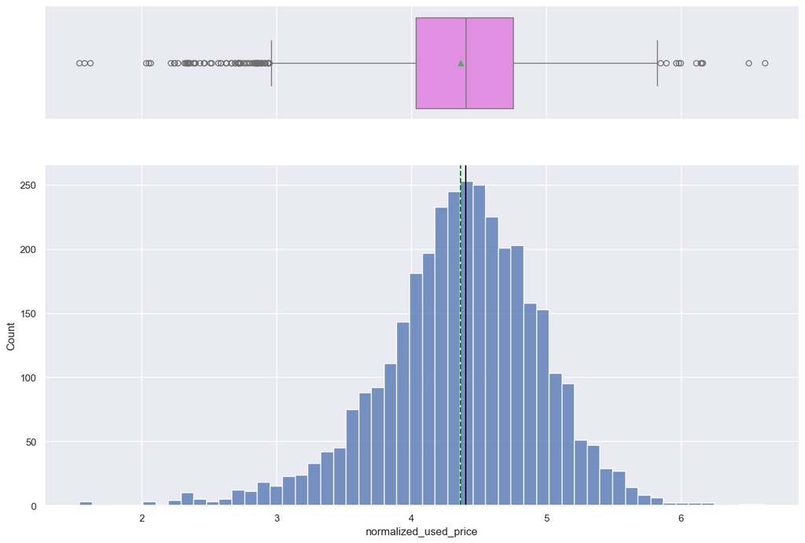

```python
histogram_boxplot(df, "normalized_used_price")
```

- The normalized_used_prices are close to normally distributed with fatter tails
- The normalized_used_prices approximately 4.5

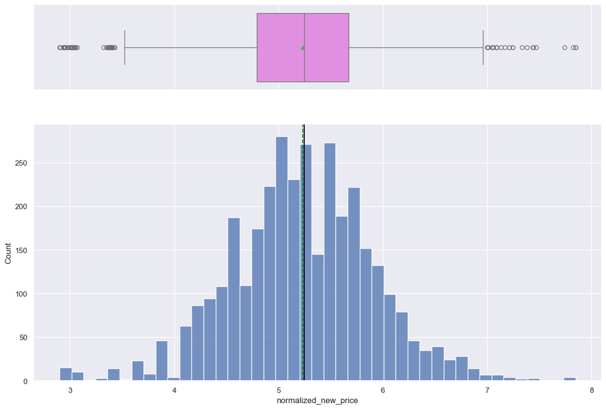

```python
histogram_boxplot(df, "normalized_new_price")
```

- The normalized_new_prices are close to normally distributed
- The normalized_new_prices approximately 5.3

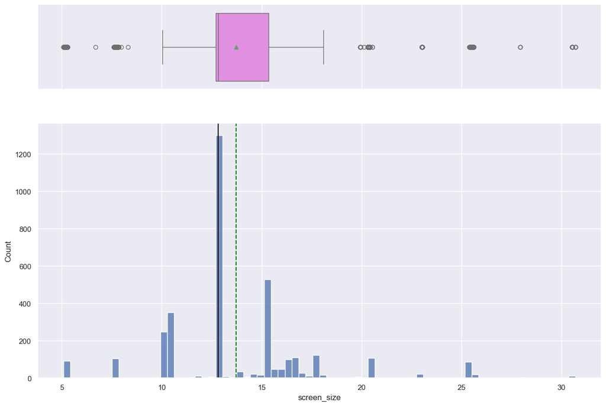

```python
histogram_boxplot(df, "screen_size")
```

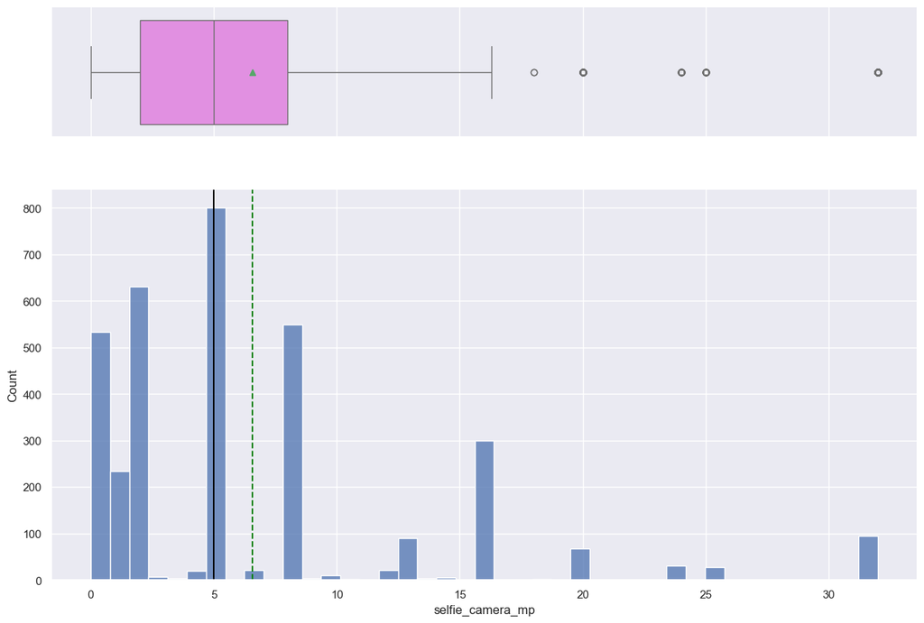

```python
histogram_boxplot(df, "selfie_camera_mp")
```

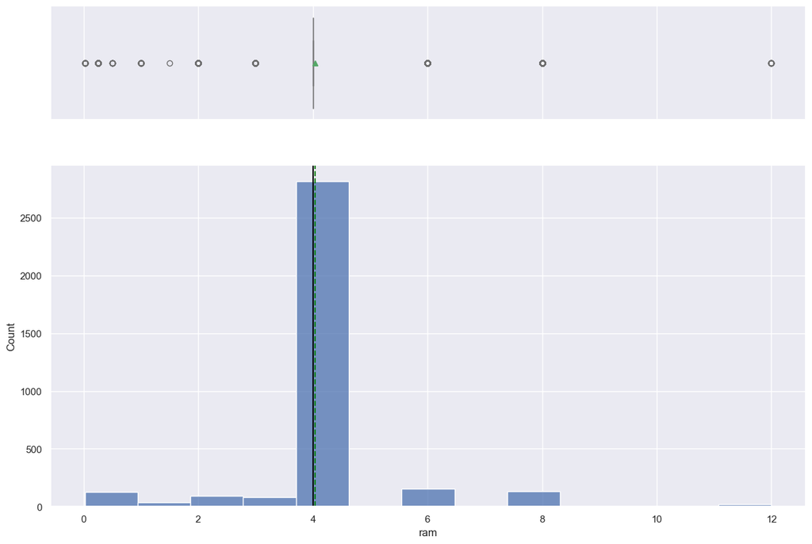

```python
histogram_boxplot(df, "ram")
```

- The dataset is heavily skewed toward 4 GB RAM, which is the dominant configuration.
- There is very little variation in RAM among most devices.
- Outliers suggest the presence of both low-end and high-end models, but they are rare.

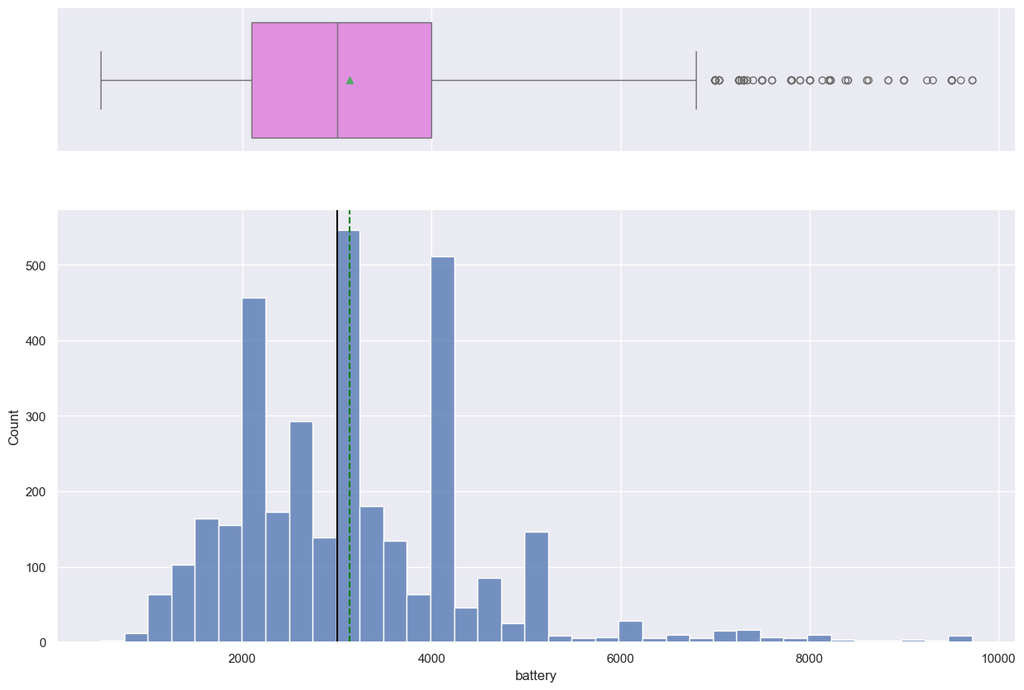

```python
histogram_boxplot(df, "battery")
```

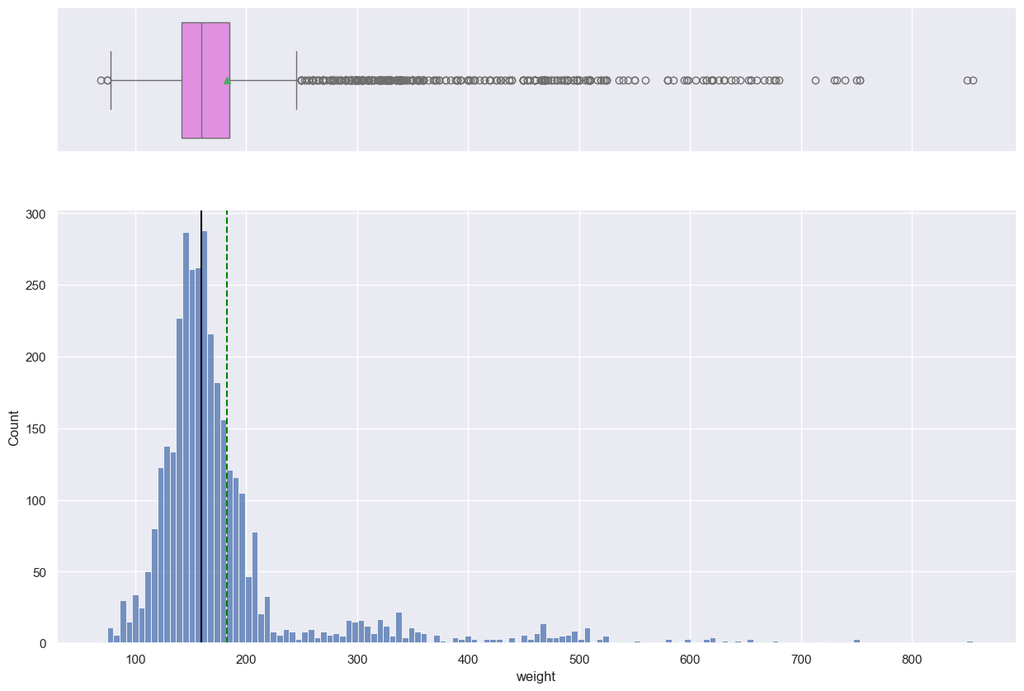

```python
histogram_boxplot(df, "weight")
```

- Most devices weigh between 130–200 grams, typical for smartphones.
- The data is right-skewed, with a long tail of heavier devices (possibly tablets, rugged phones ).
- There are many outliers above 300g, but they represent a small portion of the dataset.

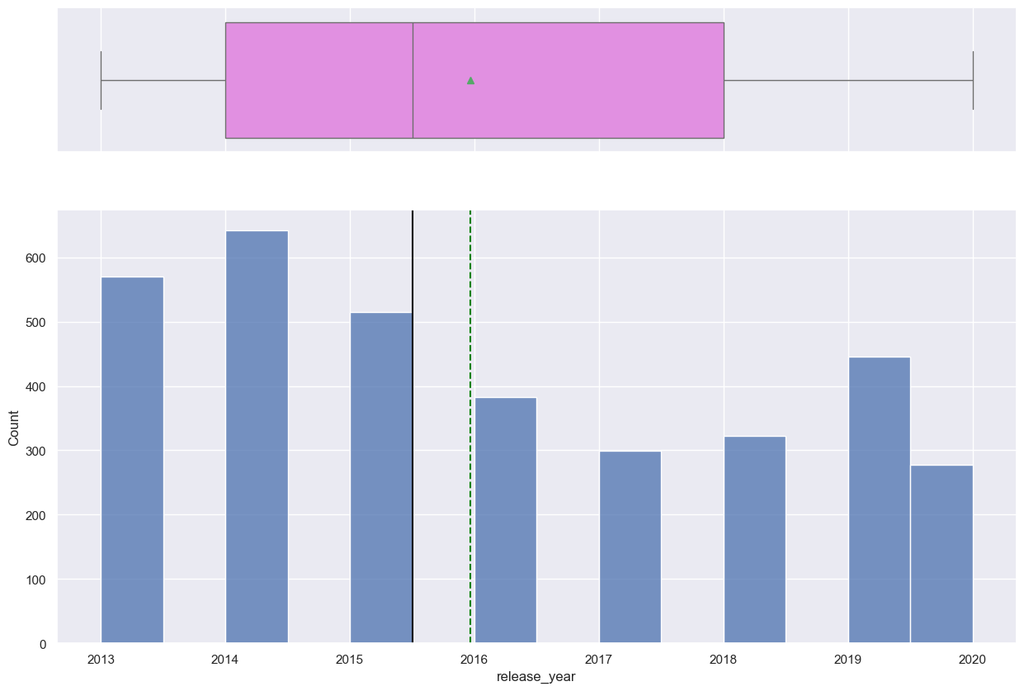

```python
histogram_boxplot(df, "release_year")
```

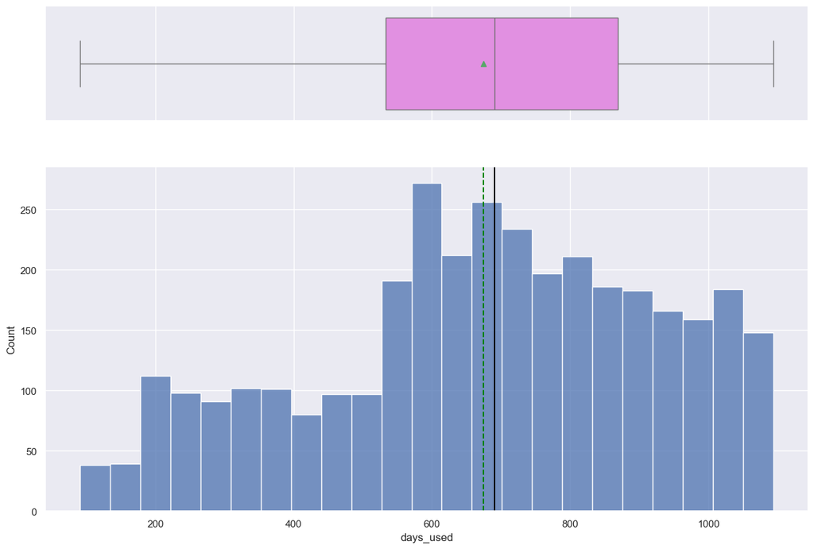

```python
histogram_boxplot(df, "days_used")
```

- Devices are typically used for 600–900 days.
- The distribution of usage is balanced and clean, with no strong skewness or outliers.

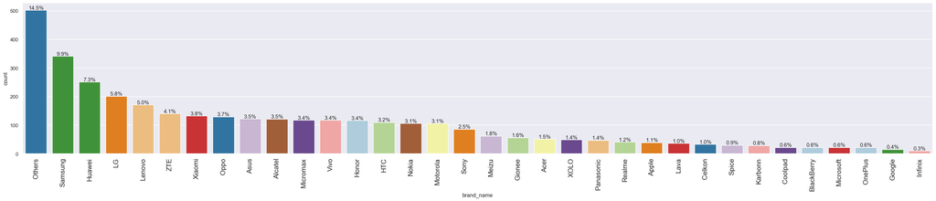

```python
labeled_barplot(df, "brand_name", perc=True)
```

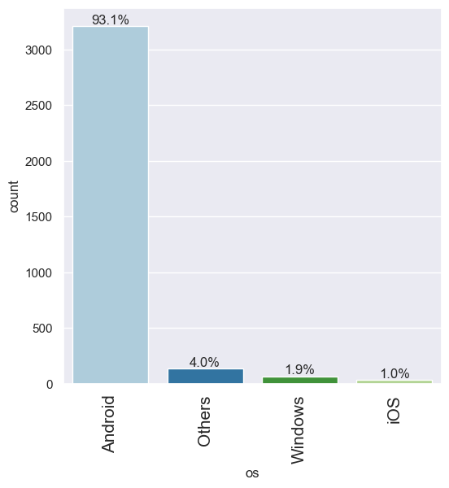

```python
labeled_barplot(df, "os", perc=True)
```

- Android dominates the dataset with 93.1% of all entries — the overwhelming majority of devices run on Android.
- Others make up 4.0%, which likely includes lesser-known or discontinued operating systems (e.g., custom OS, Linux-based variants).
- Windows holds 1.9%, likely representing older or niche smartphones that ran Windows Phone.
- iOS accounts for only 1.0%, indicating that Apple devices are underrepresented in this dataset.

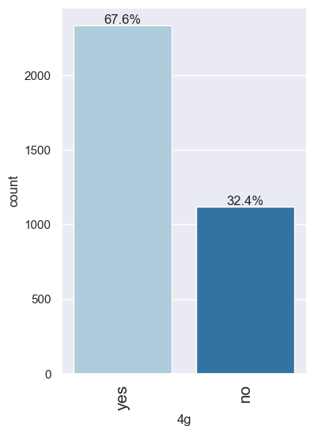

```python
labeled_barplot(df, "4g", perc=True)
```

- 67.6% of the devices support 4G (yes).
- 32.4% of the devices do not support 4G (no).
- The dataset reflects widespread adoption of 4G technology.

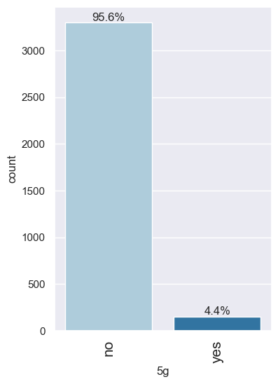

```python
labeled_barplot(df, "5g", perc=True)
```

- Only 4.4% of the devices in the dataset support 5G (yes).
- A vast 95.6% of devices do not support 5G (no).

This clearly shows that 5G technology is still relatively uncommon in the dataset, likely due to a mix of older devices or regions where 5G adoption has been slower.

```python
# creating a list of numerical columns
num_cols = df.select_dtypes(include=np.number).columns.tolist()

# dropping release_year from list of numerical column as it is not numerical in nature
num_cols.remove("release_year")
```

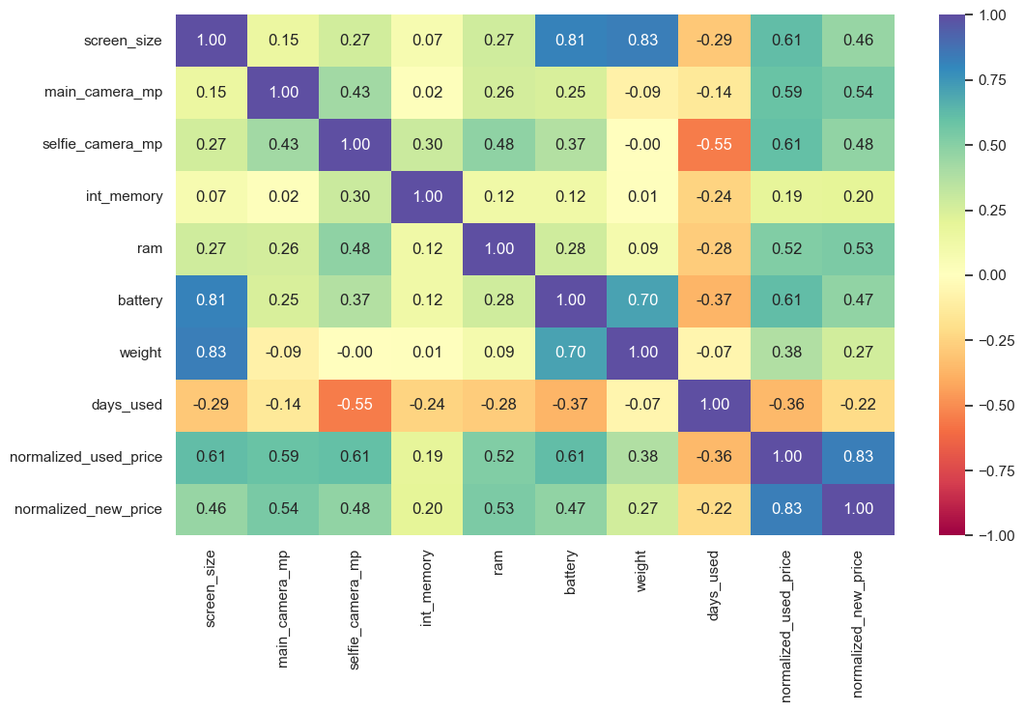

```python
plt.figure(figsize=(12, 7))
sns.heatmap(
    df[num_cols].corr(), annot=True, vmin=-1, vmax=1, fmt=".2f", cmap="Spectral"
)
plt.show()
```

#### Strong Positive Correlations:

- screen_size & weight: 0.83

→ Larger screens tend to result in heavier devices.

- screen_size & battery: 0.81

→ Bigger screens are usually paired with bigger batteries.

- battery & weight: 0.70

→ Larger batteries add more weight to the device.

- normalized_used_price & normalized_new_price: 0.83

→ Strong relationship between new and used prices (as expected).

##### normalized_used_price correlates well with:

- main_camera_mp: 0.59
- selfie_camera_mp: 0.61
- screen_size: 0.61
- battery: 0.61

#### Notable Negative Correlations:

- days_used & selfie_camera_mp: -0.55

→ Devices with better selfie cameras are typically newer or used for fewer days.

- days_used & battery: -0.37

→ Older or more heavily used devices tend to have lower battery capacity.

- days_used & normalized_used_price: -0.36

→ The longer a device has been used, the lower its resale value.

#### Other Insights:

ram and both normalized_used_price (0.52) and normalized_new_price (0.53) are moderately correlated → More RAM adds value.

int_memory has weak correlations with most variables (max ~0.30), indicating it may not be a strong driver of price or other features.

#### Summary:

- Price (both new and used) is positively influenced by screen size, camera quality, RAM, and battery.
- Device age (days_used) is negatively correlated with price, camera, and battery, as expected.
- Strong internal relationships exist among screen size, battery, and weight.

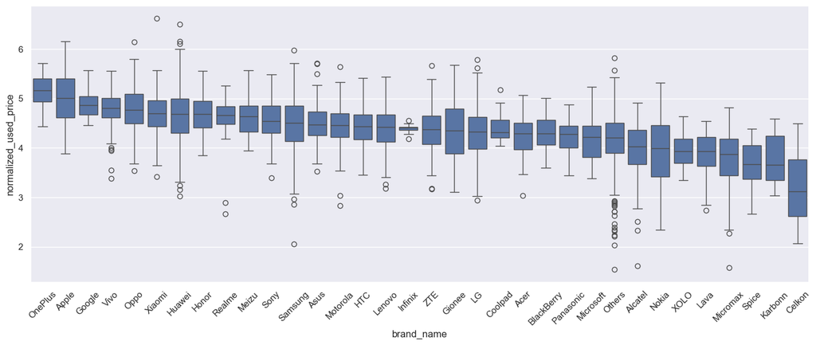

```python
order_bn = df.groupby("brand_name")["normalized_used_price"].median().sort_values(ascending=False).index

plt.figure(figsize=(14, 6))
sns.boxplot(data=df, x="brand_name", y="normalized_used_price", order=order_bn)
plt.xticks(rotation=45)
plt.tight_layout()
plt.show()
```

- OnePlus, Apple, Google, Vivo have the highest median resale values

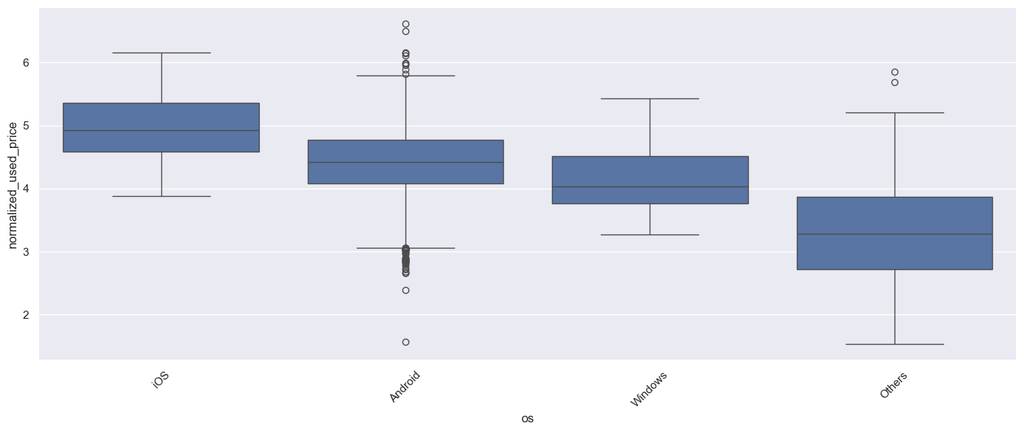

```python
order_os = df.groupby("os")["normalized_used_price"].median().sort_values(ascending=False).index

plt.figure(figsize=(14, 6))
sns.boxplot(data=df, x="os", y="normalized_used_price", order=order_os)
plt.xticks(rotation=45)
plt.tight_layout()
plt.show()
```

- iOS devices hold their value best, followed by Android.
- Windows and Other OS devices have lower and more inconsistent resale prices.

This plot supports the insight that operating system strongly influences used device value, likely due to brand perception, ecosystem lock-in, and update/support longevity.

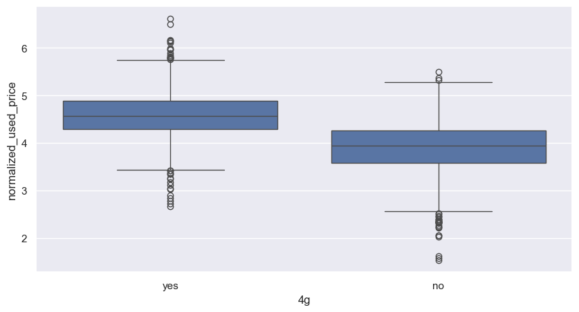

```python
plt.figure(figsize=(10, 5))
sns.boxplot(data=df, x="4g", y="normalized_used_price")
plt.show()
```

Devices with 4G support clearly retain higher used prices compared to those without.

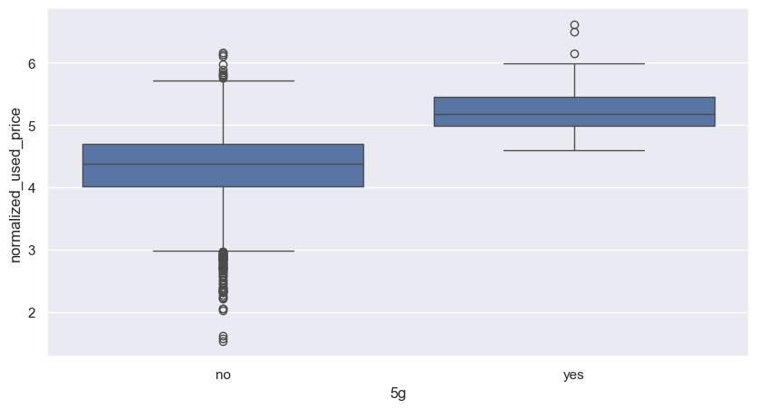

```python
plt.figure(figsize=(10, 5))
sns.boxplot(data=df, x="5g", y="normalized_used_price")
plt.show()
```

Devices with 5G support clearly retain higher used prices compared to those without.

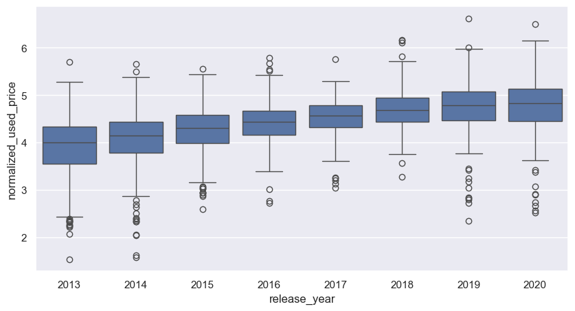

```python
plt.figure(figsize=(10, 5))
sns.boxplot(data=df, x="release_year", y="normalized_used_price")
plt.show()
```

- Used price increases with release year, as expected.
- Devices released more recently retain more value and show less variability.
- Great for modeling depreciation over time or including release_year as a feature in price prediction.

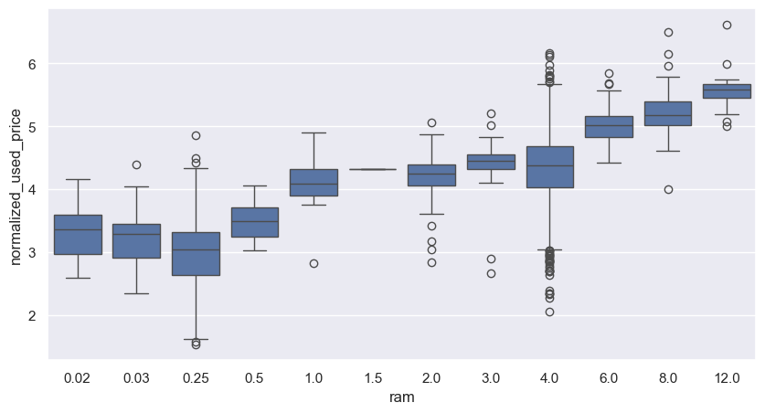

```python
plt.figure(figsize=(10, 5))
sns.boxplot(data=df, x="ram", y="normalized_used_price")
plt.show()
```

- RAM size is a strong predictor of resale value.
- Devices with ≥6 GB RAM command significantly higher and more consistent prices.

#### What does the distribution of normalized used device prices look like?

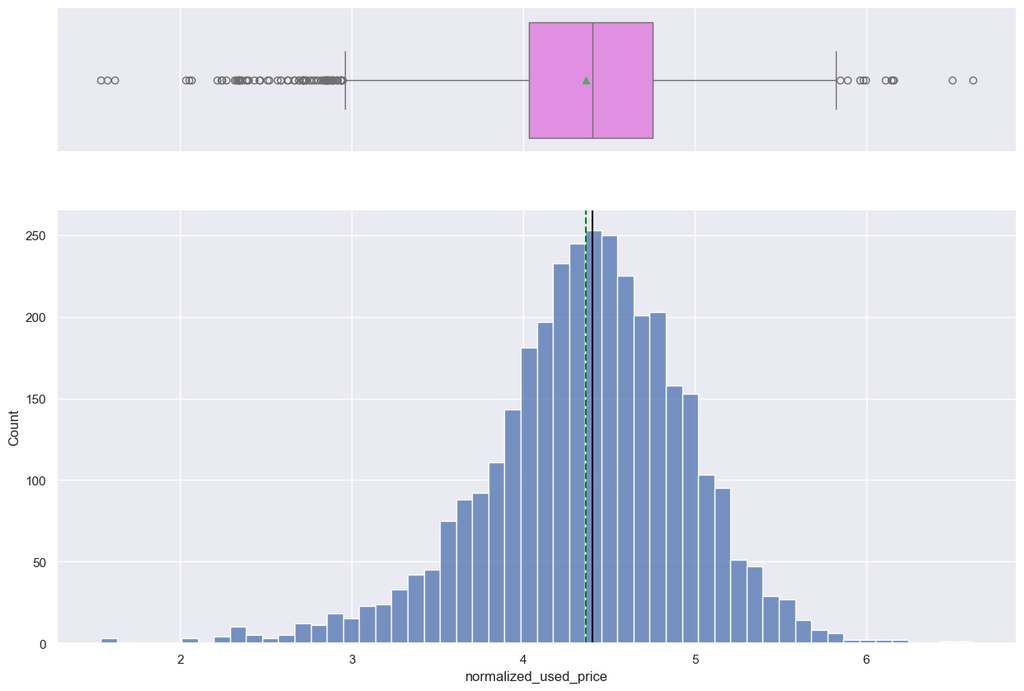

```python
histogram_boxplot(df, "normalized_used_price")
```

The normalized_used_prices are close to normally distributed with fatter tails

#### What percentage of the used device market is dominated by Android devices?

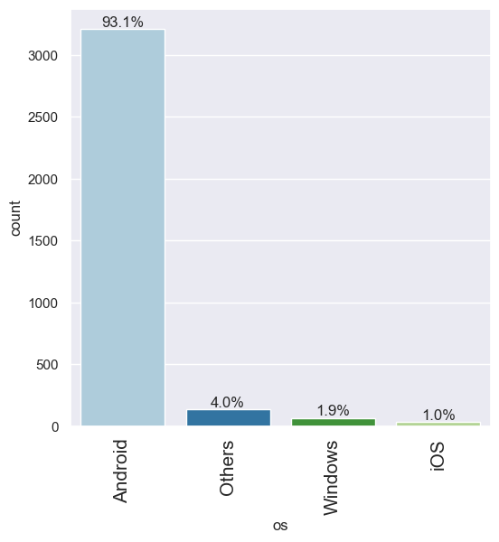

```python
labeled_barplot(df, "os", perc=True)
```

- Android dominates the dataset with 93.1% of all entries

#### The amount of RAM is important for the smooth functioning of a device. How does the amount of RAM vary with the brand?

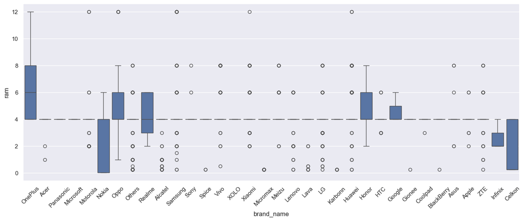

```python
order_rm = df.groupby("brand_name")["ram"].median().sort_values(ascending=False).index

plt.figure(figsize=(14, 6))
sns.boxplot(data=df, x="brand_name", y="ram", order=order_rm)
plt.xticks(rotation=45)
plt.tight_layout()
plt.show()
```

#### A large battery often increases a device's weight, making it feel uncomfortable in the hands. How does the weight vary for phones and tablets offering large batteries (more than 4500 mAh)?

```python
df_large_battery = df[df.battery > 4500]
df_large_battery.shape
```

```
(341, 15)
```

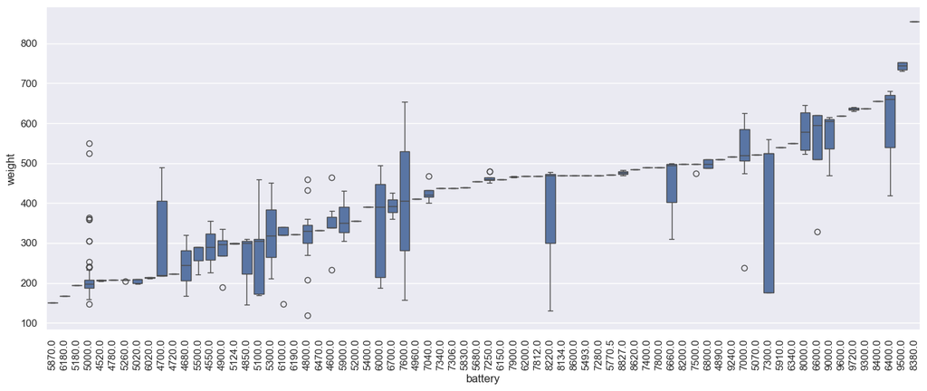

```python
order_bat= df_large_battery.groupby("battery")["weight"].median().sort_values(ascending=True).index

plt.figure(figsize=(14, 6))
sns.boxplot(data=df_large_battery, x="battery", y="weight", order=order_bat)
plt.xticks(rotation=90)
plt.tight_layout()
plt.show()
```

Larger batteries add more weight to the device.

#### Bigger screens are desirable for entertainment purposes as they offer a better viewing experience. How many phones and tablets are available across different brands with a screen size larger than 6 inches?

```python
df_large_screen = df[df.screen_size > 6 * 2.54]
df_large_screen.shape
```

```
(1099, 15)
```

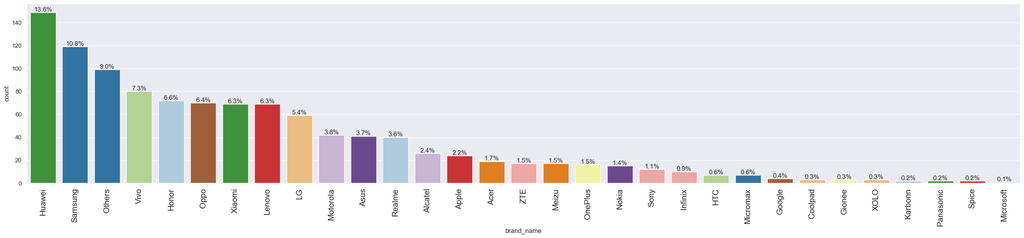

```python
labeled_barplot(df_large_screen, "brand_name", perc=True)
```

Huawei and Samsung dominate the large-screen segment.

#### A lot of devices nowadays offer great selfie cameras, allowing us to capture our favorite moments with loved ones. What is the distribution of devices offering greater than 8MP selfie cameras across brands?

```python
df_selfie_camera = df[df.selfie_camera_mp > 8]
df_selfie_camera.shape
```

```
(655, 15)
```

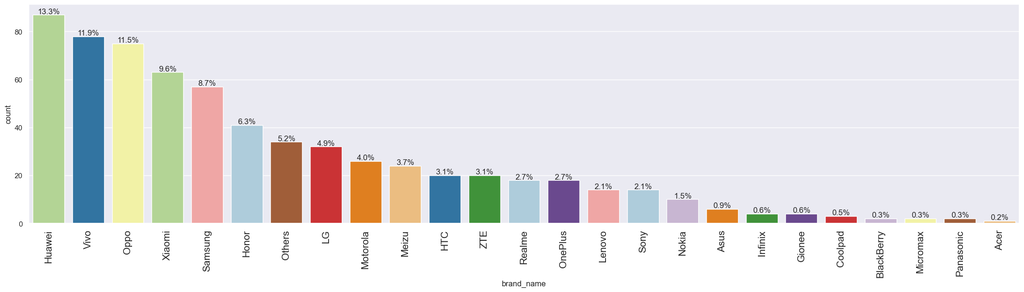

```python
labeled_barplot(df_selfie_camera, "brand_name", perc=True)
```

Huawei, Vivo, Oppo, and Xiaomi dominate the market for >8 MP selfie cameras

#### Which attributes are highly correlated with the normalized price of a used device?

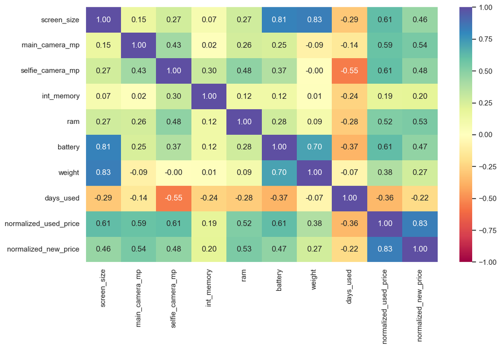

```python
plt.figure(figsize=(12, 7))
sns.heatmap(
    df[num_cols].corr(), annot=True, vmin=-1, vmax=1, fmt=".2f", cmap="Spectral"
)
plt.show()
```

##### The normalized price of a used device highly correlated with:

- normalized_new_price: 0.83
- selfie_camera_mp: 0.61
- screen_size: 0.61
- battery: 0.61
- main_camera_mp: 0.59

## Data Preprocessing

- Missing value treatment
- Feature engineering (if needed)
- Outlier detection and treatment (if needed)
- Preparing data for modeling
- Any other preprocessing steps (if needed)

### Missing value treatment

```python
df.isnull().sum()
```

```
brand_name                 0
os                         0
screen_size                0
4g                         0
5g                         0
main_camera_mp           179
selfie_camera_mp           2
int_memory                 4
ram                        4
battery                    6
weight                     7
release_year               0
days_used                  0
normalized_used_price      0
normalized_new_price       0
dtype: int64
```

We will impute the missing values in the data by the column medians grouped by release_year and brand_name.

```python
# we first create a copy of the data to avoid changes to it
df1 = df.copy()
```

```python
cols_impute = [
    "main_camera_mp",
    "selfie_camera_mp",
    "int_memory",
    "ram",
    "battery",
    "weight",
]

for col in cols_impute:
    df1[col] = df1[col].fillna(
        value=df1.groupby(["release_year", "brand_name"])[col].transform("median")
    )
```

```python
# we first create a copy of the data to avoid changes to it
df1.isnull().sum()
```

```
brand_name                 0
os                         0
screen_size                0
4g                         0
5g                         0
main_camera_mp           179
selfie_camera_mp           2
int_memory                 0
ram                        0
battery                    6
weight                     7
release_year               0
days_used                  0
normalized_used_price      0
normalized_new_price       0
dtype: int64
```

We still have missing values We will impute the remaining missing values in the data by the column medians grouped by brand_name.

```python
cols_impute = [
    "main_camera_mp",
    "selfie_camera_mp",
    "battery",
    "weight",
]

for col in cols_impute:
    df1[col] = df1[col].fillna(
        value=df1.groupby(["brand_name"])[col].transform("median")
    )
```

```python
# we first create a copy of the data to avoid changes to it
df1.isnull().sum()
```

```
brand_name                0
os                        0
screen_size               0
4g                        0
5g                        0
main_camera_mp           10
selfie_camera_mp          0
int_memory                0
ram                       0
battery                   0
weight                    0
release_year              0
days_used                 0
normalized_used_price     0
normalized_new_price      0
dtype: int64
```

```python
df1["main_camera_mp"] = df1["main_camera_mp"].fillna(df1["main_camera_mp"].median())
```

```python
# we first create a copy of the data to avoid changes to it
df1.isnull().sum()
```

```
brand_name               0
os                       0
screen_size              0
4g                       0
5g                       0
main_camera_mp           0
selfie_camera_mp         0
int_memory               0
ram                      0
battery                  0
weight                   0
release_year             0
days_used                0
normalized_used_price    0
normalized_new_price     0
dtype: int64
```

### Feature engineering (if needed)

```python
df1["years_since_release"] = 2021 - df1["release_year"]
df1.drop(["release_year"], axis=1, inplace=True)
df1.head()
```

|  | brand_name | os | screen_size | 4g | 5g | main_camera_mp | selfie_camera_mp | int_memory | ram | battery | weight | days_used | normalized_used_price | normalized_new_price | years_since_release |
| --- | --- | --- | --- | --- | --- | --- | --- | --- | --- | --- | --- | --- | --- | --- | --- |
| 0 | Honor | Android | 14.50 | yes | no | 13.0 | 5.0 | 64.0 | 3.0 | 3020.0 | 146.0 | 127 | 4.307572 | 4.715100 | 1 |
| 1 | Honor | Android | 17.30 | yes | yes | 13.0 | 16.0 | 128.0 | 8.0 | 4300.0 | 213.0 | 325 | 5.162097 | 5.519018 | 1 |
| 2 | Honor | Android | 16.69 | yes | yes | 13.0 | 8.0 | 128.0 | 8.0 | 4200.0 | 213.0 | 162 | 5.111084 | 5.884631 | 1 |
| 3 | Honor | Android | 25.50 | yes | yes | 13.0 | 8.0 | 64.0 | 6.0 | 7250.0 | 480.0 | 345 | 5.135387 | 5.630961 | 1 |
| 4 | Honor | Android | 15.32 | yes | no | 13.0 | 8.0 | 64.0 | 3.0 | 5000.0 | 185.0 | 293 | 4.389995 | 4.947837 | 1 |

### Outlier detection and treatment

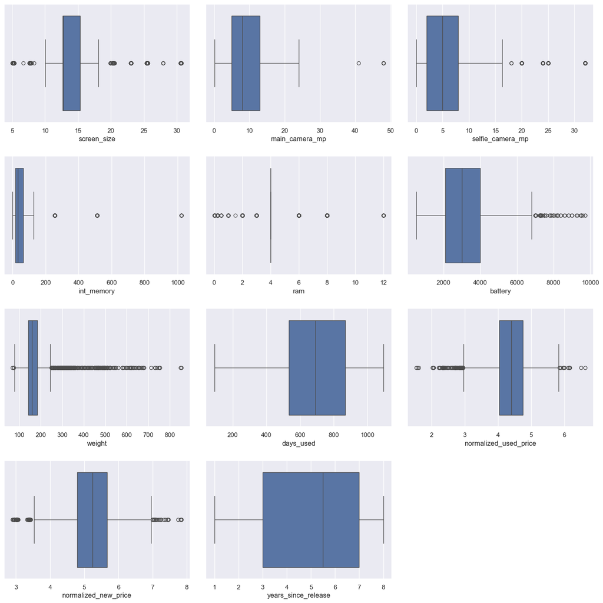

```python
# outlier detection using boxplot
num_cols = df1.select_dtypes(include=np.number).columns.tolist()

plt.figure(figsize=(15, 15))

for i, variable in enumerate(num_cols):
    plt.subplot(4, 3, i + 1)
    sns.boxplot(data=df1, x=variable)
    plt.tight_layout(pad=2)

plt.show()
```

There are quite a lot outliers in the data However, we will not treat them as they are proper values

### Preparing data for modeling

- We want to predict the normalized price of used devices
- Before we proceed to build a model, we'll have to encode categorical features
- We'll split the data into train and test to be able to evaluate the model that we build on the train data
- We will build a Linear Regression model using the train data and then check it's performance

```python
# defining X and y variables
X = df1.drop(["normalized_used_price"], axis=1)
y = df1["normalized_used_price"]

print(X.head())
print(y.head())
```

```
  brand_name       os  screen_size   4g   5g  main_camera_mp  \
0      Honor  Android        14.50  yes   no            13.0
1      Honor  Android        17.30  yes  yes            13.0
2      Honor  Android        16.69  yes  yes            13.0
3      Honor  Android        25.50  yes  yes            13.0
4      Honor  Android        15.32  yes   no            13.0

   selfie_camera_mp  int_memory  ram  battery  weight  days_used  \
0               5.0        64.0  3.0   3020.0   146.0        127
1              16.0       128.0  8.0   4300.0   213.0        325
2               8.0       128.0  8.0   4200.0   213.0        162
3               8.0        64.0  6.0   7250.0   480.0        345
4               8.0        64.0  3.0   5000.0   185.0        293

   normalized_new_price  years_since_release
0              4.715100                    1
1              5.519018                    1
2              5.884631                    1
3              5.630961                    1
4              4.947837                    1
0    4.307572
1    5.162097
2    5.111084
3    5.135387
4    4.389995
Name: normalized_used_price, dtype: float64
```

```python
# let's add the intercept to data
X = sm.add_constant(X)
```

```python
# creating dummy variables
X = pd.get_dummies(
    X,
    columns=X.select_dtypes(include=["object", "category"]).columns.tolist(),
    drop_first=True
)
X.head()
```

|  | const | screen_size | main_camera_mp | selfie_camera_mp | int_memory | ram | battery | weight | days_used | normalized_new_price | ... | brand_name_Spice | brand_name_Vivo | brand_name_XOLO | brand_name_Xiaomi | brand_name_ZTE | os_Others | os_Windows | os_iOS | 4g_yes | 5g_yes |
| --- | --- | --- | --- | --- | --- | --- | --- | --- | --- | --- | --- | --- | --- | --- | --- | --- | --- | --- | --- | --- | --- |
| 0 | 1.0 | 14.50 | 13.0 | 5.0 | 64.0 | 3.0 | 3020.0 | 146.0 | 127 | 4.715100 | ... | False | False | False | False | False | False | False | False | True | False |
| 1 | 1.0 | 17.30 | 13.0 | 16.0 | 128.0 | 8.0 | 4300.0 | 213.0 | 325 | 5.519018 | ... | False | False | False | False | False | False | False | False | True | True |
| 2 | 1.0 | 16.69 | 13.0 | 8.0 | 128.0 | 8.0 | 4200.0 | 213.0 | 162 | 5.884631 | ... | False | False | False | False | False | False | False | False | True | True |
| 3 | 1.0 | 25.50 | 13.0 | 8.0 | 64.0 | 6.0 | 7250.0 | 480.0 | 345 | 5.630961 | ... | False | False | False | False | False | False | False | False | True | True |
| 4 | 1.0 | 15.32 | 13.0 | 8.0 | 64.0 | 3.0 | 5000.0 | 185.0 | 293 | 4.947837 | ... | False | False | False | False | False | False | False | False | True | False |

5 rows × 49 columns

```python
# converting the input attributes into float type for modeling
X = X.astype(float)
X.head()
```

|  | const | screen_size | main_camera_mp | selfie_camera_mp | int_memory | ram | battery | weight | days_used | normalized_new_price | ... | brand_name_Spice | brand_name_Vivo | brand_name_XOLO | brand_name_Xiaomi | brand_name_ZTE | os_Others | os_Windows | os_iOS | 4g_yes | 5g_yes |
| --- | --- | --- | --- | --- | --- | --- | --- | --- | --- | --- | --- | --- | --- | --- | --- | --- | --- | --- | --- | --- | --- |
| 0 | 1.0 | 14.50 | 13.0 | 5.0 | 64.0 | 3.0 | 3020.0 | 146.0 | 127.0 | 4.715100 | ... | 0.0 | 0.0 | 0.0 | 0.0 | 0.0 | 0.0 | 0.0 | 0.0 | 1.0 | 0.0 |
| 1 | 1.0 | 17.30 | 13.0 | 16.0 | 128.0 | 8.0 | 4300.0 | 213.0 | 325.0 | 5.519018 | ... | 0.0 | 0.0 | 0.0 | 0.0 | 0.0 | 0.0 | 0.0 | 0.0 | 1.0 | 1.0 |
| 2 | 1.0 | 16.69 | 13.0 | 8.0 | 128.0 | 8.0 | 4200.0 | 213.0 | 162.0 | 5.884631 | ... | 0.0 | 0.0 | 0.0 | 0.0 | 0.0 | 0.0 | 0.0 | 0.0 | 1.0 | 1.0 |
| 3 | 1.0 | 25.50 | 13.0 | 8.0 | 64.0 | 6.0 | 7250.0 | 480.0 | 345.0 | 5.630961 | ... | 0.0 | 0.0 | 0.0 | 0.0 | 0.0 | 0.0 | 0.0 | 0.0 | 1.0 | 1.0 |
| 4 | 1.0 | 15.32 | 13.0 | 8.0 | 64.0 | 3.0 | 5000.0 | 185.0 | 293.0 | 4.947837 | ... | 0.0 | 0.0 | 0.0 | 0.0 | 0.0 | 0.0 | 0.0 | 0.0 | 1.0 | 0.0 |

5 rows × 49 columns

```python
# splitting the data in 70:30 ratio for train to test data

x_train, x_test, y_train, y_test = train_test_split(X, y, test_size=0.3, random_state=1)
```

```python
print("Number of rows in train data =", x_train.shape[0])
print("Number of rows in test data =", x_test.shape[0])
```

```
Number of rows in train data = 2417
Number of rows in test data = 1037
```

## Model Building - Linear Regression

```python
olsmodel = sm.OLS(y_train, x_train).fit()
print(olsmodel.summary())
```

```
                              OLS Regression Results
=================================================================================
Dep. Variable:     normalized_used_price   R-squared:                       0.845
Model:                               OLS   Adj. R-squared:                  0.842
Method:                    Least Squares   F-statistic:                     268.7
Date:                   Sun, 01 Jun 2025   Prob (F-statistic):               0.00
Time:                           22:01:49   Log-Likelihood:                 123.85
No. Observations:                   2417   AIC:                            -149.7
Df Residuals:                       2368   BIC:                             134.0
Df Model:                             48
Covariance Type:               nonrobust
=========================================================================================
                            coef    std err          t      P>|t|      [0.025      0.975]
-----------------------------------------------------------------------------------------
const                     1.3156      0.071     18.454      0.000       1.176       1.455
screen_size               0.0244      0.003      7.163      0.000       0.018       0.031
main_camera_mp            0.0208      0.002     13.848      0.000       0.018       0.024
selfie_camera_mp          0.0135      0.001     11.997      0.000       0.011       0.016
int_memory                0.0001   6.97e-05      1.651      0.099   -2.16e-05       0.000
ram                       0.0230      0.005      4.451      0.000       0.013       0.033
battery               -1.689e-05   7.27e-06     -2.321      0.020   -3.12e-05   -2.62e-06
weight                    0.0010      0.000      7.480      0.000       0.001       0.001
days_used              4.216e-05   3.09e-05      1.366      0.172   -1.84e-05       0.000
normalized_new_price      0.4311      0.012     35.147      0.000       0.407       0.455
years_since_release      -0.0237      0.005     -5.193      0.000      -0.033      -0.015
brand_name_Alcatel        0.0154      0.048      0.323      0.747      -0.078       0.109
brand_name_Apple         -0.0038      0.147     -0.026      0.980      -0.292       0.285
brand_name_Asus           0.0151      0.048      0.314      0.753      -0.079       0.109
brand_name_BlackBerry    -0.0300      0.070     -0.427      0.669      -0.168       0.108
brand_name_Celkon        -0.0468      0.066     -0.707      0.480      -0.177       0.083
brand_name_Coolpad        0.0209      0.073      0.287      0.774      -0.122       0.164
brand_name_Gionee         0.0448      0.058      0.775      0.438      -0.068       0.158
brand_name_Google        -0.0326      0.085     -0.385      0.700      -0.199       0.133
brand_name_HTC           -0.0130      0.048     -0.270      0.787      -0.108       0.081
brand_name_Honor          0.0317      0.049      0.644      0.520      -0.065       0.128
brand_name_Huawei        -0.0020      0.044     -0.046      0.964      -0.089       0.085
brand_name_Infinix        0.1633      0.093      1.752      0.080      -0.019       0.346
brand_name_Karbonn        0.0943      0.067      1.405      0.160      -0.037       0.226
brand_name_LG            -0.0132      0.045     -0.291      0.771      -0.102       0.076
brand_name_Lava           0.0332      0.062      0.533      0.594      -0.089       0.155
```

[output cut: 19 more lines]

```
os_Windows               -0.0207      0.045     -0.459      0.646      -0.109       0.068
os_iOS                   -0.0663      0.146     -0.453      0.651      -0.354       0.221
4g_yes                    0.0528      0.016      3.326      0.001       0.022       0.084
5g_yes                   -0.0714      0.031     -2.268      0.023      -0.133      -0.010
==============================================================================
Omnibus:                      223.612   Durbin-Watson:                   1.910
Prob(Omnibus):                  0.000   Jarque-Bera (JB):              422.275
Skew:                          -0.620   Prob(JB):                     2.01e-92
Kurtosis:                       4.630   Cond. No.                     1.78e+05
==============================================================================

Notes:
[1] Standard Errors assume that the covariance matrix of the errors is correctly specified.
[2] The condition number is large, 1.78e+05. This might indicate that there are
strong multicollinearity or other numerical problems.
```

## Model Performance Check

Let's check the performance of the model using different metrics.

- We will be using metric functions defined in sklearn for RMSE, MAE, and $R^2$.
- We will define a function to calculate MAPE and adjusted $R^2$.
  - The mean absolute percentage error (MAPE) measures the accuracy of predictions as a percentage, and can be calculated as the average absolute percent error for each predicted value minus actual values divided by actual values. It works best if there are no extreme values in the data and none of the actual values are 0.
- We will create a function which will print out all the above metrics in one go.

```python
# function to compute adjusted R-squared
def adj_r2_score(predictors, targets, predictions):
    r2 = r2_score(targets, predictions)
    n = predictors.shape[0]
    k = predictors.shape[1]
    return 1 - ((1 - r2) * (n - 1) / (n - k - 1))


# function to compute MAPE
def mape_score(targets, predictions):
    return np.mean(np.abs(targets - predictions) / targets) * 100


# function to compute different metrics to check performance of a regression model
def model_performance_regression(model, predictors, target):
    """
    Function to compute different metrics to check regression model performance

    model: regressor
    predictors: independent variables
    target: dependent variable
    """

    # predicting using the independent variables
    pred = model.predict(predictors)

    r2 = r2_score(target, pred)  # to compute R-squared
    adjr2 = adj_r2_score(predictors, target, pred)  # to compute adjusted R-squared
    rmse = np.sqrt(mean_squared_error(target, pred))  # to compute RMSE
    mae = mean_absolute_error(target, pred)  # to compute MAE
    mape = mape_score(target, pred)  # to compute MAPE

    # creating a dataframe of metrics
    df_perf = pd.DataFrame(
        {
            "RMSE": rmse,
            "MAE": mae,
            "R-squared": r2,
            "Adj. R-squared": adjr2,
            "MAPE": mape,
        },
        index=[0],
    )

    return df_perf
```

```python
# checking model performance on train set (seen 70% data)
print("Training Performance\n")
olsmodel_train_perf = model_performance_regression(olsmodel, x_train, y_train)
olsmodel_train_perf
```

```
Training Performance
```

|  | RMSE | MAE | R-squared | Adj. R-squared | MAPE |
| --- | --- | --- | --- | --- | --- |
| 0 | 0.229884 | 0.180326 | 0.844886 | 0.841675 | 4.326841 |

```python
# checking model performance on test set (seen 30% data)
print("Test Performance\n")
olsmodel_test_perf = model_performance_regression(olsmodel, x_test, y_test)
olsmodel_test_perf
```

```
Test Performance
```

|  | RMSE | MAE | R-squared | Adj. R-squared | MAPE |
| --- | --- | --- | --- | --- | --- |
| 0 | 0.238358 | 0.184749 | 0.842479 | 0.834659 | 4.501651 |

# **Observations**

- The training R² value of **0.84** indicates that the model captures most of the variance in the data and is **not underfitting**.
- The test metrics are very close to the training metrics, indicating **no overfitting** — the model generalizes well.
- The **MAE of 0.18** on the test data suggests the model’s predictions are on average **±0.18 units** away from the actual normalized price.
- The **MAPE of 4.5%** indicates that the model can predict used prices with an average **relative error of just 4.5%**, which is very good for regression tasks.

## Checking Linear Regression Assumptions

- In order to make statistical inferences from a linear regression model, it is important to ensure that the assumptions of linear regression are satisfied.

We will be checking the following Linear Regression assumptions:

1. **No Multicollinearity**
2. **Linearity of variables**
3. **Independence of error terms**
4. **Normality of error terms**
5. **No Heteroscedasticity**
- Multicollinearity occurs when predictor variables in a regression model are correlated. This correlation is a problem because predictor variables should be independent. If the correlation between variables is high, it can cause problems when we fit the model and interpret the results. When we have multicollinearity in the linear model, the coefficients that the model suggests are unreliable.
- There are different ways of detecting (or testing) multicollinearity. One such way is by using the Variance Inflation Factor, or VIF.
- **Variance Inflation Factor (VIF)**: Variance inflation factors measure the inflation in the variances of the regression parameter estimates due to collinearities that exist among the predictors. It is a measure of how much the variance of the estimated regression coefficient $\beta_k$ is "inflated" by the existence of correlation among the predictor variables in the model.
  - If VIF is 1, then there is no correlation among the $k$th predictor and the remaining predictor variables, and hence, the variance of $\beta_k$ is not inflated at all.
- **General Rule of thumb**:
  - If VIF is between 1 and 5, then there is low multicollinearity.
  - If VIF is between 5 and 10, we say there is moderate multicollinearity.
  - If VIF is exceeding 10, it shows signs of high multicollinearity.

```python
from statsmodels.stats.outliers_influence import variance_inflation_factor


def checking_vif(predictors):
    vif = pd.DataFrame()
    vif["feature"] = predictors.columns

    # calculating VIF for each feature
    vif["VIF"] = [
        variance_inflation_factor(predictors.values, i)
        for i in range(len(predictors.columns))
    ]
    return vif
```

```python
checking_vif(x_train)
```

|  | feature | VIF |
| --- | --- | --- |
| 0 | const | 227.744081 |
| 1 | screen_size | 7.677290 |
| 2 | main_camera_mp | 2.285051 |
| 3 | selfie_camera_mp | 2.812473 |
| 4 | int_memory | 1.364152 |
| 5 | ram | 2.282352 |
| 6 | battery | 4.081780 |
| 7 | weight | 6.396749 |
| 8 | days_used | 2.660269 |
| 9 | normalized_new_price | 3.119430 |
| 10 | years_since_release | 4.899007 |
| 11 | brand_name_Alcatel | 3.405693 |
| 12 | brand_name_Apple | 13.057668 |
| 13 | brand_name_Asus | 3.332038 |
| 14 | brand_name_BlackBerry | 1.632378 |
| 15 | brand_name_Celkon | 1.774721 |
| 16 | brand_name_Coolpad | 1.468006 |
| 17 | brand_name_Gionee | 1.951272 |
| 18 | brand_name_Google | 1.321778 |
| 19 | brand_name_HTC | 3.410361 |
| 20 | brand_name_Honor | 3.340687 |
| 21 | brand_name_Huawei | 5.983852 |
| 22 | brand_name_Infinix | 1.283955 |
| 23 | brand_name_Karbonn | 1.573702 |
| 24 | brand_name_LG | 4.849832 |
| 25 | brand_name_Lava | 1.711360 |
| 26 | brand_name_Lenovo | 4.558941 |
| 27 | brand_name_Meizu | 2.179607 |
| 28 | brand_name_Micromax | 3.363521 |
| 29 | brand_name_Microsoft | 1.869751 |
| 30 | brand_name_Motorola | 3.274558 |
| 31 | brand_name_Nokia | 3.479849 |
| 32 | brand_name_OnePlus | 1.437034 |
| 33 | brand_name_Oppo | 3.971194 |
| 34 | brand_name_Others | 9.711034 |
| 35 | brand_name_Panasonic | 2.105703 |
| 36 | brand_name_Realme | 1.946812 |
| 37 | brand_name_Samsung | 7.539866 |
| 38 | brand_name_Sony | 2.943161 |
| 39 | brand_name_Spice | 1.688863 |
| 40 | brand_name_Vivo | 3.651437 |
| 41 | brand_name_XOLO | 2.138070 |
| 42 | brand_name_Xiaomi | 3.719689 |
| 43 | brand_name_ZTE | 3.797581 |
| 44 | os_Others | 1.859863 |
| 45 | os_Windows | 1.596034 |
| 46 | os_iOS | 11.784684 |
| 47 | 4g_yes | 2.467681 |
| 48 | 5g_yes | 1.813900 |

- There are multiple columns with very high VIF values, indicating presence of strong multicollinearity
- We will systematically drop numerical columns with VIF > 5
- We will ignore the VIF values for dummy variables and the constant (intercept)

### Removing Multicollinearity

To remove multicollinearity

1. Drop every column one by one that has a VIF score greater than 5.
2. Look at the adjusted R-squared and RMSE of all these models.
3. Drop the variable that makes the least change in adjusted R-squared.
4. Check the VIF scores again.
5. Continue till you get all VIF scores under 5.

Let's define a function that will help us do this.

```python
def treating_multicollinearity(predictors, target, high_vif_columns):
    """
    Checking the effect of dropping the columns showing high multicollinearity
    on model performance (adj. R-squared and RMSE)

    predictors: independent variables
    target: dependent variable
    high_vif_columns: columns having high VIF
    """
    # empty lists to store adj. R-squared and RMSE values
    adj_r2 = []
    rmse = []

    # build ols models by dropping one of the high VIF columns at a time
    # store the adjusted R-squared and RMSE in the lists defined previously
    for cols in high_vif_columns:
        # defining the new train set
        train = predictors.loc[:, ~predictors.columns.str.startswith(cols)]

        # create the model
        olsmodel = sm.OLS(target, train).fit()

        # adding adj. R-squared and RMSE to the lists
        adj_r2.append(olsmodel.rsquared_adj)
        rmse.append(np.sqrt(olsmodel.mse_resid))

    # creating a dataframe for the results
    temp = pd.DataFrame(
        {
            "col": high_vif_columns,
            "Adj. R-squared after_dropping col": adj_r2,
            "RMSE after dropping col": rmse,
        }
    ).sort_values(by="Adj. R-squared after_dropping col", ascending=False)
    temp.reset_index(drop=True, inplace=True)

    return temp
```

```python
col_list = ["screen_size", "weight"]

res = treating_multicollinearity(x_train, y_train, col_list)
res
```

|  | col | Adj. R-squared after_dropping col | RMSE after dropping col |
| --- | --- | --- | --- |
| 0 | screen_size | 0.838381 | 0.234703 |
| 1 | weight | 0.838071 | 0.234928 |

```python
col_to_drop = "weight"
x_train2 = x_train.loc[:, ~x_train.columns.str.startswith(col_to_drop)]
x_test2 = x_test.loc[:, ~x_test.columns.str.startswith(col_to_drop)]

# Check VIF now
vif = checking_vif(x_train2)
print("VIF after dropping ", col_to_drop)
vif
```

```
VIF after dropping  weight
```

|  | feature | VIF |
| --- | --- | --- |
| 0 | const | 208.983030 |
| 1 | screen_size | 3.593184 |
| 2 | main_camera_mp | 2.188817 |
| 3 | selfie_camera_mp | 2.787946 |
| 4 | int_memory | 1.364018 |
| 5 | ram | 2.280390 |
| 6 | battery | 3.681135 |
| 7 | days_used | 2.648280 |
| 8 | normalized_new_price | 3.116297 |
| 9 | years_since_release | 4.726722 |
| 10 | brand_name_Alcatel | 3.405634 |
| 11 | brand_name_Apple | 13.052085 |
| 12 | brand_name_Asus | 3.329527 |
| 13 | brand_name_BlackBerry | 1.632331 |
| 14 | brand_name_Celkon | 1.774249 |
| 15 | brand_name_Coolpad | 1.467932 |
| 16 | brand_name_Gionee | 1.951224 |
| 17 | brand_name_Google | 1.321656 |
| 18 | brand_name_HTC | 3.408430 |
| 19 | brand_name_Honor | 3.339066 |
| 20 | brand_name_Huawei | 5.983684 |
| 21 | brand_name_Infinix | 1.282407 |
| 22 | brand_name_Karbonn | 1.573621 |
| 23 | brand_name_LG | 4.849000 |
| 24 | brand_name_Lava | 1.711137 |
| 25 | brand_name_Lenovo | 4.557575 |
| 26 | brand_name_Meizu | 2.179175 |
| 27 | brand_name_Micromax | 3.363424 |
| 28 | brand_name_Microsoft | 1.867689 |
| 29 | brand_name_Motorola | 3.269552 |
| 30 | brand_name_Nokia | 3.474548 |
| 31 | brand_name_OnePlus | 1.436740 |
| 32 | brand_name_Oppo | 3.971169 |
| 33 | brand_name_Others | 9.680324 |
| 34 | brand_name_Panasonic | 2.105687 |
| 35 | brand_name_Realme | 1.946779 |
| 36 | brand_name_Samsung | 7.537336 |
| 37 | brand_name_Sony | 2.939161 |
| 38 | brand_name_Spice | 1.686997 |
| 39 | brand_name_Vivo | 3.650722 |
| 40 | brand_name_XOLO | 2.136746 |
| 41 | brand_name_Xiaomi | 3.719683 |
| 42 | brand_name_ZTE | 3.795623 |
| 43 | os_Others | 1.744860 |
| 44 | os_Windows | 1.596034 |
| 45 | os_iOS | 11.750869 |
| 46 | 4g_yes | 2.447780 |
| 47 | 5g_yes | 1.811783 |

We have dealt with multicollinearity in the data

Let's rebuild the model using the updated set of predictors variables

```python
olsmod1 = sm.OLS(y_train, x_train2).fit()
print(olsmod1.summary())
```

```
                              OLS Regression Results
=================================================================================
Dep. Variable:     normalized_used_price   R-squared:                       0.841
Model:                               OLS   Adj. R-squared:                  0.838
Method:                    Least Squares   F-statistic:                     267.0
Date:                   Sun, 01 Jun 2025   Prob (F-statistic):               0.00
Time:                           22:01:51   Log-Likelihood:                 95.629
No. Observations:                   2417   AIC:                            -95.26
Df Residuals:                       2369   BIC:                             182.7
Df Model:                             47
Covariance Type:               nonrobust
=========================================================================================
                            coef    std err          t      P>|t|      [0.025      0.975]
-----------------------------------------------------------------------------------------
const                     1.1626      0.069     16.829      0.000       1.027       1.298
screen_size               0.0430      0.002     18.235      0.000       0.038       0.048
main_camera_mp            0.0185      0.001     12.437      0.000       0.016       0.021
selfie_camera_mp          0.0127      0.001     11.219      0.000       0.010       0.015
int_memory                0.0001   7.05e-05      1.559      0.119   -2.83e-05       0.000
ram                       0.0218      0.005      4.186      0.000       0.012       0.032
battery                1.609e-07   6.99e-06      0.023      0.982   -1.35e-05    1.39e-05
days_used              5.766e-05   3.11e-05      1.851      0.064   -3.42e-06       0.000
normalized_new_price      0.4340      0.012     34.999      0.000       0.410       0.458
years_since_release      -0.0173      0.005     -3.815      0.000      -0.026      -0.008
brand_name_Alcatel        0.0139      0.048      0.288      0.773      -0.081       0.108
brand_name_Apple         -0.0265      0.149     -0.178      0.858      -0.318       0.265
brand_name_Asus           0.0249      0.048      0.514      0.607      -0.070       0.120
brand_name_BlackBerry    -0.0272      0.071     -0.383      0.702      -0.166       0.112
brand_name_Celkon        -0.0387      0.067     -0.578      0.563      -0.170       0.093
brand_name_Coolpad        0.0248      0.074      0.336      0.737      -0.120       0.169
brand_name_Gionee         0.0426      0.058      0.730      0.466      -0.072       0.157
brand_name_Google        -0.0265      0.086     -0.310      0.757      -0.194       0.141
brand_name_HTC           -0.0045      0.049     -0.091      0.927      -0.100       0.091
brand_name_Honor          0.0236      0.050      0.474      0.636      -0.074       0.121
brand_name_Huawei        -0.0003      0.045     -0.006      0.995      -0.088       0.088
brand_name_Infinix        0.1391      0.094      1.476      0.140      -0.046       0.324
brand_name_Karbonn        0.0907      0.068      1.336      0.182      -0.042       0.224
brand_name_LG            -0.0087      0.046     -0.191      0.849      -0.099       0.081
brand_name_Lava           0.0279      0.063      0.442      0.659      -0.096       0.151
brand_name_Lenovo         0.0512      0.046      1.121      0.263      -0.038       0.141
```

[output cut: 18 more lines]

```
os_Windows               -0.0207      0.046     -0.454      0.650      -0.110       0.069
os_iOS                   -0.0076      0.148     -0.052      0.959      -0.298       0.282
4g_yes                    0.0421      0.016      2.634      0.008       0.011       0.073
5g_yes                   -0.0634      0.032     -1.991      0.047      -0.126      -0.001
==============================================================================
Omnibus:                      210.155   Durbin-Watson:                   1.917
Prob(Omnibus):                  0.000   Jarque-Bera (JB):              379.188
Skew:                          -0.603   Prob(JB):                     4.57e-83
Kurtosis:                       4.520   Cond. No.                     1.78e+05
==============================================================================

Notes:
[1] Standard Errors assume that the covariance matrix of the errors is correctly specified.
[2] The condition number is large, 1.78e+05. This might indicate that there are
strong multicollinearity or other numerical problems.
```

### Interpreting the Regression Results:

4. **std err**: It reflects the level of accuracy of the coefficients.
   - The lower it is, the higher is the level of accuracy.
5. **P>|t|**: It is p-value.
   - For each independent feature, there is a null hypothesis and an alternate hypothesis. Here $\beta_i$ is the coefficient of the $i$th independent variable.
     - $H_o$ : Independent feature is not significant ($\beta_i = 0$)
     - $H_a$ : Independent feature is that it is significant ($\beta_i \neq 0$)
   - (P>|t|) gives the p-value for each independent feature to check that null hypothesis. We are considering 0.05 (5%) as significance level.
     - A p-value of less than 0.05 is considered to be statistically significant.
6. **Confidence Interval**: It represents the range in which our coefficients are likely to fall (with a likelihood of 95%).

**Observations**

- We can see that adj. R-squared has dropped from 0.842 to 0.838, which shows that the dropped columns did not have much effect on the model
- As there is no multicollinearity, we can look at the p-values of predictor variables to check their significance

### Dealing with high p-value variables

- Some of the dummy variables in the data have p-value > 0.05. So, they are not significant and we'll drop them
- But sometimes p-values change after dropping a variable. So, we'll not drop all variables at once
- Instead, we will do the following:
  - Build a model, check the p-values of the variables, and drop the column with the highest p-value
  - Create a new model without the dropped feature, check the p-values of the variables, and drop the column with the highest p-value
  - Repeat the above two steps till there are no columns with p-value > 0.05

**Note**: The above process can also be done manually by picking one variable at a time that has a high p-value, dropping it, and building a model again. But that might be a little tedious and using a loop will be more efficient.

```python
# initial list of columns
predictors = x_train2.copy()
cols = predictors.columns.tolist()

# setting an initial max p-value
max_p_value = 1

while len(cols) > 0:
    # defining the train set
    x_train_aux = predictors[cols]

    # fitting the model
    model = sm.OLS(y_train, x_train_aux).fit()

    # getting the p-values and the maximum p-value
    p_values = model.pvalues
    max_p_value = max(p_values)

    # name of the variable with maximum p-value
    feature_with_p_max = p_values.idxmax()

    if max_p_value > 0.05:
        cols.remove(feature_with_p_max)
    else:
        break

selected_features = cols
print(selected_features)
```

```
['const', 'screen_size', 'main_camera_mp', 'selfie_camera_mp', 'ram', 'days_used', 'normalized_new_price', 'years_since_release', 'brand_name_Lenovo', 'brand_name_Nokia', 'brand_name_Xiaomi', '4g_yes']
```

```python
x_train3 = x_train2[selected_features]
x_test3 = x_test2[selected_features]
```

```python
olsmod2 = sm.OLS(y_train, x_train3).fit()
print(olsmod2.summary())
```

```
                              OLS Regression Results
=================================================================================
Dep. Variable:     normalized_used_price   R-squared:                       0.839
Model:                               OLS   Adj. R-squared:                  0.839
Method:                    Least Squares   F-statistic:                     1142.
Date:                   Sun, 01 Jun 2025   Prob (F-statistic):               0.00
Time:                           22:01:51   Log-Likelihood:                 81.071
No. Observations:                   2417   AIC:                            -138.1
Df Residuals:                       2405   BIC:                            -68.66
Df Model:                             11
Covariance Type:               nonrobust
========================================================================================
                           coef    std err          t      P>|t|      [0.025      0.975]
----------------------------------------------------------------------------------------
const                    1.2119      0.046     26.274      0.000       1.121       1.302
screen_size              0.0433      0.002     28.306      0.000       0.040       0.046
main_camera_mp           0.0189      0.001     13.938      0.000       0.016       0.022
selfie_camera_mp         0.0131      0.001     12.372      0.000       0.011       0.015
ram                      0.0172      0.004      3.914      0.000       0.009       0.026
days_used             6.226e-05   3.03e-05      2.052      0.040    2.75e-06       0.000
normalized_new_price     0.4282      0.011     39.576      0.000       0.407       0.449
years_since_release     -0.0181      0.004     -4.184      0.000      -0.027      -0.010
brand_name_Lenovo        0.0489      0.022      2.261      0.024       0.006       0.091
brand_name_Nokia         0.0733      0.030      2.458      0.014       0.015       0.132
brand_name_Xiaomi        0.0852      0.026      3.320      0.001       0.035       0.135
4g_yes                   0.0369      0.015      2.456      0.014       0.007       0.066
==============================================================================
Omnibus:                      217.147   Durbin-Watson:                   1.916
Prob(Omnibus):                  0.000   Jarque-Bera (JB):              403.764
Skew:                          -0.610   Prob(JB):                     2.11e-88
Kurtosis:                       4.588   Cond. No.                     7.13e+03
==============================================================================

Notes:
[1] Standard Errors assume that the covariance matrix of the errors is correctly specified.
[2] The condition number is large, 7.13e+03. This might indicate that there are
strong multicollinearity or other numerical problems.
```

```python
# checking model performance on train set (seen 70% data)
print("Training Performance\n")
olsmod2_train_perf = model_performance_regression(olsmod2, x_train3, y_train)
olsmod2_train_perf
```

```
Training Performance
```

|  | RMSE | MAE | R-squared | Adj. R-squared | MAPE |
| --- | --- | --- | --- | --- | --- |
| 0 | 0.233989 | 0.183177 | 0.839296 | 0.838494 | 4.392265 |

```python
# checking model performance on test set (seen 30% data)
print("Test Performance\n")
olsmod2_test_perf = model_performance_regression(olsmod2, x_test3, y_test)
olsmod2_test_perf
```

```
Test Performance
```

|  | RMSE | MAE | R-squared | Adj. R-squared | MAPE |
| --- | --- | --- | --- | --- | --- |
| 0 | 0.238554 | 0.185 | 0.84222 | 0.840371 | 4.500963 |

### Observations

- All the predictor variables in `x_train3` now have **p-values < 0.05**, indicating they are **statistically significant**. Therefore, we will consider `x_train3` as the final set of predictors and `olsmod2` as the **final model** moving forward.
- The **Adjusted R-squared** of the model is **0.839**, which means the model explains approximately **83.9% of the variance** in the normalized used price. This reflects strong explanatory power.
- Compared to earlier versions of the model, this shows that removing multicollinear or statistically insignificant features has **not adversely impacted performance**.
- The **RMSE** and **MAE** values are **very similar** between training and test sets:
  - **Train MAE:** 0.1832 vs **Test MAE:** 0.1850
  - **Train RMSE:** 0.2339 vs **Test RMSE:** 0.2386

  This confirms that the model is **not overfitting** and generalizes well.
- The **MAPE** on the test set is **4.50%**, indicating the model can predict used prices within an **average relative error of ±4.5%**, which is highly acceptable for regression tasks.

**Now we'll check the rest of the assumptions on *olsmod2*.**

2. **Linearity of variables**
3. **Independence of error terms**
4. **Normality of error terms**
5. **No Heteroscedasticity**

### TEST FOR LINEARITY AND INDEPENDENCE

**Why the test?**

- Linearity describes a straight-line relationship between two variables, predictor variables must have a linear relation with the dependent variable.
- The independence of the error terms (or residuals) is important. If the residuals are not independent, then the confidence intervals of the coefficient estimates will be narrower and make us incorrectly conclude a parameter to be statistically significant.

**How to check linearity and independence?**

- Make a plot of fitted values vs residuals.
- If they don't follow any pattern, then we say the model is linear and residuals are independent.
- Otherwise, the model is showing signs of non-linearity and residuals are not independent.

**How to fix if this assumption is not followed?**

- We can try to transform the variables and make the relationships linear.

```python
# let us create a dataframe with actual, fitted and residual values
df_pred = pd.DataFrame()

df_pred["Actual Values"] = y_train  # actual values
df_pred["Fitted Values"] = olsmod2.fittedvalues  # predicted values
df_pred["Residuals"] = olsmod2.resid  # residuals

df_pred.head()
```

|  | Actual Values | Fitted Values | Residuals |
| --- | --- | --- | --- |
| 3026 | 4.087488 | 3.858599 | 0.228888 |
| 1525 | 4.448399 | 4.613833 | -0.165434 |
| 1128 | 4.315353 | 4.277568 | 0.037785 |
| 3003 | 4.282068 | 4.252225 | 0.029844 |
| 2907 | 4.456438 | 4.440283 | 0.016156 |

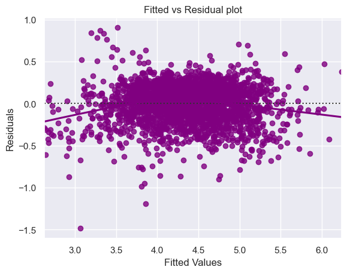

```python
# let's plot the fitted values vs residuals

sns.residplot(
    data=df_pred, x="Fitted Values", y="Residuals", color="purple", lowess=True
)
plt.xlabel("Fitted Values")
plt.ylabel("Residuals")
plt.title("Fitted vs Residual plot")
plt.show()
```

- The scatter plot shows the distribution of residuals (errors) vs fitted values (predicted values).
- If there exist any pattern in this plot, we consider it as signs of non-linearity in the data and a pattern means that the model doesn't capture non-linear effects.
- **We see no pattern in the plot above. Hence, the assumptions of linearity and independence are satisfied.**

### TEST FOR NORMALITY

**Why the test?**

- Error terms, or residuals, should be normally distributed. If the error terms are not normally distributed, confidence intervals of the coefficient estimates may become too wide or narrow. Once confidence interval becomes unstable, it leads to difficulty in estimating coefficients based on minimization of least squares. Non-normality suggests that there are a few unusual data points that must be studied closely to make a better model.

**How to check normality?**

- The shape of the histogram of residuals can give an initial idea about the normality.
- It can also be checked via a Q-Q plot of residuals. If the residuals follow a normal distribution, they will make a straight line plot, otherwise not.
- Other tests to check for normality includes the Shapiro-Wilk test.
  - Null hypothesis: Residuals are normally distributed
  - Alternate hypothesis: Residuals are not normally distributed

**How to fix if this assumption is not followed?**

- We can apply transformations like log, exponential, arcsinh, etc. as per our data.

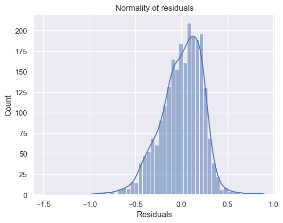

```python
sns.histplot(data=df_pred, x="Residuals", kde=True)
plt.title("Normality of residuals")
plt.show()
```

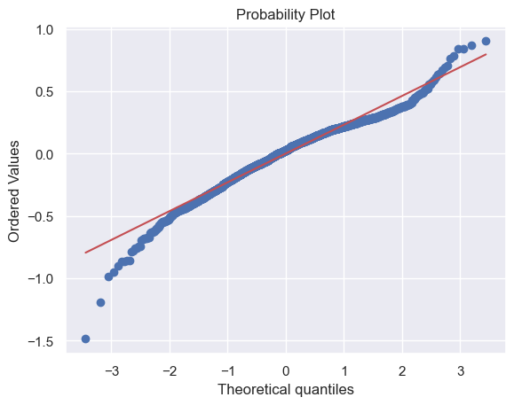

```python
import pylab
import scipy.stats as stats

stats.probplot(df_pred["Residuals"], dist="norm", plot=pylab)
plt.show()
```

- The residuals more or less follow a straight line except for the tails.
- Let's check the results of the Shapiro-Wilk test.

```python
stats.shapiro(df_pred["Residuals"])
```

```
ShapiroResult(statistic=0.9724019647308447, pvalue=3.462926954250618e-21)
```

- Null hypothesis (H₀): Residuals are normally distributed
- Alternative hypothesis (H₁): Residuals are not normally distributed
- The p-value is extremely small (<< 0.05), which means we reject the null hypothesis.

**Conclusion from test:** Statistically, the residuals are not perfectly normally distributed.

- Visually, residuals approximate normality well enough for practical purposes, especially in the central region.
- The Shapiro-Wilk test is highly sensitive to even small deviations, especially with large sample sizes — so a low p-value does not necessarily mean poor model quality.
- Since the Q-Q plot shows only minor deviations at the extremes, the residual distribution is likely sufficiently normal for linear regression assumptions to hold.

### TEST FOR HOMOSCEDASTICITY

- **Homoscedascity**: If the variance of the residuals is symmetrically distributed across the regression line, then the data is said to be homoscedastic.
- **Heteroscedascity**: If the variance is unequal for the residuals across the regression line, then the data is said to be heteroscedastic.

**Why the test?**

- The presence of non-constant variance in the error terms results in heteroscedasticity. Generally, non-constant variance arises in presence of outliers.

**How to check for homoscedasticity?**

- The residual vs fitted values plot can be looked at to check for homoscedasticity. In the case of heteroscedasticity, the residuals can form an arrow shape or any other non-symmetrical shape.
- The goldfeldquandt test can also be used. If we get a p-value > 0.05 we can say that the residuals are homoscedastic. Otherwise, they are heteroscedastic.
  - Null hypothesis: Residuals are homoscedastic
  - Alternate hypothesis: Residuals have heteroscedasticity

**How to fix if this assumption is not followed?**

- Heteroscedasticity can be fixed by adding other important features or making transformations.

```python
import statsmodels.stats.api as sms
from statsmodels.compat import lzip

name = ["F statistic", "p-value"]
test = sms.het_goldfeldquandt(df_pred["Residuals"], x_train3)
lzip(name, test)
```

```
[('F statistic', 1.055490250999203), ('p-value', 0.17520491832999693)]
```

**Since p-value > 0.05, we can say that the residuals are homoscedastic. So, this assumption is satisfied.**

## Predictions on test data

```python
# predictions on the test set
pred = olsmod2.predict(x_test3)

df_pred_test = pd.DataFrame({"Actual": y_test, "Predicted": pred})
df_pred_test.sample(10, random_state=1)
```

|  | Actual | Predicted |
| --- | --- | --- |
| 1995 | 4.566741 | 4.370046 |
| 2341 | 3.696103 | 3.954403 |
| 1913 | 3.592093 | 3.760742 |
| 688 | 4.306495 | 4.099280 |
| 650 | 4.522115 | 5.117977 |
| 2291 | 4.259294 | 4.392088 |
| 40 | 4.997685 | 5.404365 |
| 1884 | 3.875359 | 4.103732 |
| 2538 | 4.206631 | 4.044604 |
| 45 | 5.380450 | 5.301336 |

- We can observe here that our model has returned pretty good prediction results, and the actual and predicted values are comparable

## Final Model

```python
x_train_final = x_train3.copy()
x_test_final = x_test3.copy()
```

```python
olsmodel_final = sm.OLS(y_train, x_train_final).fit()
print(olsmodel_final.summary())
```

```
                              OLS Regression Results
=================================================================================
Dep. Variable:     normalized_used_price   R-squared:                       0.839
Model:                               OLS   Adj. R-squared:                  0.839
Method:                    Least Squares   F-statistic:                     1142.
Date:                   Sun, 01 Jun 2025   Prob (F-statistic):               0.00
Time:                           22:01:55   Log-Likelihood:                 81.071
No. Observations:                   2417   AIC:                            -138.1
Df Residuals:                       2405   BIC:                            -68.66
Df Model:                             11
Covariance Type:               nonrobust
========================================================================================
                           coef    std err          t      P>|t|      [0.025      0.975]
----------------------------------------------------------------------------------------
const                    1.2119      0.046     26.274      0.000       1.121       1.302
screen_size              0.0433      0.002     28.306      0.000       0.040       0.046
main_camera_mp           0.0189      0.001     13.938      0.000       0.016       0.022
selfie_camera_mp         0.0131      0.001     12.372      0.000       0.011       0.015
ram                      0.0172      0.004      3.914      0.000       0.009       0.026
days_used             6.226e-05   3.03e-05      2.052      0.040    2.75e-06       0.000
normalized_new_price     0.4282      0.011     39.576      0.000       0.407       0.449
years_since_release     -0.0181      0.004     -4.184      0.000      -0.027      -0.010
brand_name_Lenovo        0.0489      0.022      2.261      0.024       0.006       0.091
brand_name_Nokia         0.0733      0.030      2.458      0.014       0.015       0.132
brand_name_Xiaomi        0.0852      0.026      3.320      0.001       0.035       0.135
4g_yes                   0.0369      0.015      2.456      0.014       0.007       0.066
==============================================================================
Omnibus:                      217.147   Durbin-Watson:                   1.916
Prob(Omnibus):                  0.000   Jarque-Bera (JB):              403.764
Skew:                          -0.610   Prob(JB):                     2.11e-88
Kurtosis:                       4.588   Cond. No.                     7.13e+03
==============================================================================

Notes:
[1] Standard Errors assume that the covariance matrix of the errors is correctly specified.
[2] The condition number is large, 7.13e+03. This might indicate that there are
strong multicollinearity or other numerical problems.
```

```python
# checking model performance on train set (seen 70% data)
print("Training Performance\n")
olsmodel_final_train_perf = model_performance_regression(
    olsmodel_final, x_train_final, y_train
)
olsmodel_final_train_perf
```

```
Training Performance
```

|  | RMSE | MAE | R-squared | Adj. R-squared | MAPE |
| --- | --- | --- | --- | --- | --- |
| 0 | 0.233989 | 0.183177 | 0.839296 | 0.838494 | 4.392265 |

```python
# checking model performance on test set (seen 30% data)
print("Test Performance\n")
olsmodel_final_test_perf = model_performance_regression(
    olsmodel_final, x_test_final, y_test
)
olsmodel_final_test_perf
```

```
Test Performance
```

|  | RMSE | MAE | R-squared | Adj. R-squared | MAPE |
| --- | --- | --- | --- | --- | --- |
| 0 | 0.238554 | 0.185 | 0.84222 | 0.840371 | 4.500963 |

### Model Summary

- The final model explains approximately **83.9% of the variance** in the normalized used phone prices — indicating a **strong fit** to the data.
- **Train and test RMSE and MAE values are low and very close**, which suggests the model is **not overfitting** and **generalizes well**.
- The **MAPE on the test set is 4.50%**, meaning the model can predict prices within an **average relative error of just ±4.5%**, which is excellent for practical applications.
- Therefore, we conclude that the model `olsmodel_final` is well-suited for **both prediction and inference**.

## Actionable Insights and Recommendations

1. The model explains nearly **84% of the variation** in used phone prices and can **predict prices with ~4.5% error** on unseen data.
   - This makes it a **reliable model** for both pricing strategies and understanding market drivers.
2. **A 1-unit increase in screen size** is associated with an **increase of 0.0433 units** in normalized price, keeping other variables constant.
   - Larger screens contribute positively to value — manufacturers can promote larger displays as a selling point.
3. **Higher camera specifications** also increase value:
   - `main_camera_mp`: +0.0189 units
   - `selfie_camera_mp`: +0.0131 units
   - Phones with better cameras tend to retain higher used value. Marketing can highlight camera features.
4. **RAM** contributes positively (+0.0172), reinforcing the importance of memory for buyers.
5. **Years since release** has a negative effect (–0.0181 per year), as expected — older phones lose value over time.
6. Certain brands (e.g., `Xiaomi`, `Nokia`, `Lenovo`) have a positive brand effect on value:
   - `Xiaomi`: +0.0852
   - `Nokia`: +0.0733
   - `Lenovo`: +0.0489
7. Phones with **4G support** are valued **+0.0369 units higher** than those without — connectivity continues to influence price.
8. The company can:
   - Use this model to **automate or guide pricing** of used devices.
   - **Promote phones** with large screens, high RAM, and better cameras to increase resale appeal.
   - Highlight **brand value and connectivity features** when targeting used phone markets.